# R-Assignment_Markdown

Qi Mu

October 8, 2018

## Import data

The project structure is R-Assignment Code: store the script for this project Data: store the orginal (input) files Instruction: store the assignment instruction Output: store all the output files First load date from local folder. `../Data/file` was used because that is where I stored my input files.`../` represent going up a level, similar to unix system. *The web address based loading data does not work here.

```r
library(tidyverse)
Geno <- read_tsv("../Data/fang_et_al_genotypes.txt", col_names = T )
SNP <- read_tsv("../Data/snp_position.txt")
```

## Data inspection

There are many ways to inspect the data. Below is a list of functions we can do. However, I masked certain fucntions because they will produce too large outputs. These actions can be done for smaller sized dateframes. `head()` is showing the similiar results as by looking at the data itself (both are showing the tibble of the first few rows), so I masked it as well.

```r
Geno
```

```
## # A tibble: 2,782 x 986
##    Sample_ID JG_OTU  Group abph1.20 abph1.22 ae1.3 ae1.4 ae1.5 an1.4 ba1.6
##    <chr>     <chr>   <chr> <chr>    <chr>    <chr> <chr> <chr> <chr> <chr>
##  1 SL-15     T-aust~ TRIPS ?/?      ?/?      T/T   G/G   T/T   C/C   ?/?
##  2 SL-16     T-aust~ TRIPS ?/?      ?/?      T/T   ?/?   T/T   C/C   A/G
##  3 SL-11     T-brav~ TRIPS ?/?      ?/?      T/T   G/G   T/T   ?/?   G/G
##  4 SL-12     T-brav~ TRIPS ?/?      ?/?      T/T   G/G   T/T   C/C   G/G
##  5 SL-18     T-cund  TRIPS ?/?      ?/?      T/T   G/G   T/T   C/C   ?/?
##  6 SL-2      T-dact~ TRIPS ?/?      ?/?      T/T   G/G   T/T   C/C   A/G
##  7 SL-4      T-dact~ TRIPS ?/?      ?/?      T/T   G/G   T/T   C/C   G/G
##  8 SL-6      T-dact~ TRIPS ?/?      ?/?      T/T   G/G   T/T   C/C   ?/?
##  9 SL-7      T-dact~ TRIPS ?/?      ?/?      T/T   G/G   T/T   C/C   G/G
## 10 SL-5      T-dact~ TRIPS ?/?      ?/?      T/T   G/G   T/T   C/C   ?/?
## # ... with 2,772 more rows, and 976 more variables: ba1.9 <chr>,
## #   bt2.5 <chr>, bt2.7 <chr>, bt2.8 <chr>, Fea2.1 <chr>, Fea2.5 <chr>,
## #   id1.3 <chr>, lg2.11 <chr>, lg2.2 <chr>, pbf1.1 <chr>, pbf1.2 <chr>,
## #   pbf1.3 <chr>, pbf1.5 <chr>, pbf1.6 <chr>, pbf1.7 <chr>, pbf1.8 <chr>,
## #   PZA00003.11 <chr>, PZA00004.2 <chr>, PZA00005.8 <chr>,
## #   PZA00005.9 <chr>, PZA00006.13 <chr>, PZA00006.14 <chr>,
## #   PZA00008.1 <chr>, PZA00010.5 <chr>, PZA00013.10 <chr>,
## #   PZA00013.11 <chr>, PZA00013.9 <chr>, PZA00015.4 <chr>,
## #   PZA00017.1 <chr>, PZA00018.5 <chr>, PZA00029.11 <chr>,
## #   PZA00029.12 <chr>, PZA00030.11 <chr>, PZA00031.5 <chr>,
## #   PZA00041.3 <chr>, PZA00042.2 <chr>, PZA00042.5 <chr>,
## #   PZA00043.7 <chr>, PZA00045.1 <chr>, PZA00047.2 <chr>,
## #   PZA00049.12 <chr>, PZA00050.9 <chr>, PZA00051.2 <chr>,
## #   PZA00058.5 <chr>, PZA00058.6 <chr>, PZA00060.2 <chr>,
## #   PZA00061.1 <chr>, PZA00065.2 <chr>, PZA00069.4 <chr>,
## #   PZA00070.5 <chr>, PZA00078.2 <chr>, PZA00079.1 <chr>,
## #   PZA00081.17 <chr>, PZA00084.2 <chr>, PZA00084.3 <chr>,
## #   PZA00086.8 <chr>, PZA00088.3 <chr>, PZA00090.2 <chr>,
## #   PZA00092.1 <chr>, PZA00092.5 <chr>, PZA00093.2 <chr>,
## #   PZA00096.26 <chr>, PZA00097.13 <chr>, PZA00098.14 <chr>,
## #   PZA00100.10 <chr>, PZA00100.12 <chr>, PZA00100.14 <chr>,
## #   PZA00100.9 <chr>, PZA00103.20 <chr>, PZA00106.9 <chr>,
## #   PZA00107.18 <chr>, PZA00108.12 <chr>, PZA00108.14 <chr>,
## #   PZA00108.15 <chr>, PZA00109.3 <chr>, PZA00109.5 <chr>,
## #   PZA00111.2 <chr>, PZA00111.4 <chr>, PZA00111.5 <chr>,
## #   PZA00111.6 <chr>, PZA00111.8 <chr>, PZA00114.3 <chr>,
## #   PZA00116.2 <chr>, PZA00119.4 <chr>, PZA00120.4 <chr>,
## #   PZA00123.1 <chr>, PZA00125.2 <chr>, PZA00131.14 <chr>,
## #   PZA00132.17 <chr>, PZA00132.18 <chr>, PZA00132.3 <chr>,
## #   PZA00135.6 <chr>, PZA00137.2 <chr>, PZA00139.14 <chr>,
## #   PZA00140.10 <chr>, PZA00140.6 <chr>, PZA00140.9 <chr>,
## #   PZA00142.6 <chr>, PZA00148.2 <chr>, PZA00153.3 <chr>, ...
```

```r
#head(Geno)
tail(Geno)
```

```
## # A tibble: 6 x 986
##   Sample_ID JG_OTU   Group abph1.20 abph1.22 ae1.3 ae1.4 ae1.5 an1.4 ba1.6
##   <chr>     <chr>    <chr> <chr>    <chr>    <chr> <chr> <chr> <chr> <chr>
## 1 SYN262    Zmm-IL-~ ZMMIL C/C      A/A      T/T   G/G   C/C   C/C   G/G
## 2 S0398     Zmm-IL-~ ZMMIL G/G      A/A      T/T   G/G   C/C   C/C   G/G
## 3 S1636     Zmm-IL-~ ZMMIL G/G      A/A      T/T   G/G   C/C   C/C   G/G
## 4 CU0201    Zmm-IL-~ ZMMIL C/C      A/A      T/T   G/G   C/C   C/C   G/G
## 5 S0215     Zmm-IL-~ ZMMIL G/G      A/A      T/T   ?/?   C/C   C/C   G/G
## 6 CU0202    Zmm-IL-~ ZMMIL C/C      A/A      T/T   G/G   C/C   C/C   ?/?
## # ... with 976 more variables: ba1.9 <chr>, bt2.5 <chr>, bt2.7 <chr>,
## #   bt2.8 <chr>, Fea2.1 <chr>, Fea2.5 <chr>, id1.3 <chr>, lg2.11 <chr>,
## #   lg2.2 <chr>, pbf1.1 <chr>, pbf1.2 <chr>, pbf1.3 <chr>, pbf1.5 <chr>,
## #   pbf1.6 <chr>, pbf1.7 <chr>, pbf1.8 <chr>, PZA00003.11 <chr>,
## #   PZA00004.2 <chr>, PZA00005.8 <chr>, PZA00005.9 <chr>,
## #   PZA00006.13 <chr>, PZA00006.14 <chr>, PZA00008.1 <chr>,
## #   PZA00010.5 <chr>, PZA00013.10 <chr>, PZA00013.11 <chr>,
## #   PZA00013.9 <chr>, PZA00015.4 <chr>, PZA00017.1 <chr>,
## #   PZA00018.5 <chr>, PZA00029.11 <chr>, PZA00029.12 <chr>,
## #   PZA00030.11 <chr>, PZA00031.5 <chr>, PZA00041.3 <chr>,
## #   PZA00042.2 <chr>, PZA00042.5 <chr>, PZA00043.7 <chr>,
## #   PZA00045.1 <chr>, PZA00047.2 <chr>, PZA00049.12 <chr>,
## #   PZA00050.9 <chr>, PZA00051.2 <chr>, PZA00058.5 <chr>,
## #   PZA00058.6 <chr>, PZA00060.2 <chr>, PZA00061.1 <chr>,
## #   PZA00065.2 <chr>, PZA00069.4 <chr>, PZA00070.5 <chr>,
## #   PZA00078.2 <chr>, PZA00079.1 <chr>, PZA00081.17 <chr>,
## #   PZA00084.2 <chr>, PZA00084.3 <chr>, PZA00086.8 <chr>,
## #   PZA00088.3 <chr>, PZA00090.2 <chr>, PZA00092.1 <chr>,
## #   PZA00092.5 <chr>, PZA00093.2 <chr>, PZA00096.26 <chr>,
## #   PZA00097.13 <chr>, PZA00098.14 <chr>, PZA00100.10 <chr>,
## #   PZA00100.12 <chr>, PZA00100.14 <chr>, PZA00100.9 <chr>,
## #   PZA00103.20 <chr>, PZA00106.9 <chr>, PZA00107.18 <chr>,
## #   PZA00108.12 <chr>, PZA00108.14 <chr>, PZA00108.15 <chr>,
## #   PZA00109.3 <chr>, PZA00109.5 <chr>, PZA00111.2 <chr>,
## #   PZA00111.4 <chr>, PZA00111.5 <chr>, PZA00111.6 <chr>,
## #   PZA00111.8 <chr>, PZA00114.3 <chr>, PZA00116.2 <chr>,
## #   PZA00119.4 <chr>, PZA00120.4 <chr>, PZA00123.1 <chr>,
## #   PZA00125.2 <chr>, PZA00131.14 <chr>, PZA00132.17 <chr>,
## #   PZA00132.18 <chr>, PZA00132.3 <chr>, PZA00135.6 <chr>,
## #   PZA00137.2 <chr>, PZA00139.14 <chr>, PZA00140.10 <chr>,
## #   PZA00140.6 <chr>, PZA00140.9 <chr>, PZA00142.6 <chr>,
## #   PZA00148.2 <chr>, PZA00153.3 <chr>, ...
```

```r
dim(Geno)
```

```
## [1] 2782  986
```

```r
#str(Geno)
is.list(Geno)
```

```
## [1] TRUE
```

```r
is.matrix(Geno)
```

```
## [1] FALSE
```

```r
is.data.frame(Geno)
```

```
## [1] TRUE
```

```r
#colnames(Geno)

SNP
```

```
## # A tibble: 983 x 15
##    SNP_ID   cdv_marker_id Chromosome Position  alt_pos mult_positions
##    <chr>            <int> <chr>      <chr>     <chr>   <chr>
##  1 abph1.20          5976 2          27403404  <NA>    <NA>
##  2 abph1.22          5978 2          27403892  <NA>    <NA>
##  3 ae1.3             6605 5          167889790 <NA>    <NA>
##  4 ae1.4             6606 5          167889682 <NA>    <NA>
##  5 ae1.5             6607 5          167889821 <NA>    <NA>
##  6 an1.4             5982 1          240498509 <NA>    <NA>
##  7 ba1.6             3463 3          181362952 <NA>    <NA>
##  8 ba1.9             3466 3          181362666 <NA>    <NA>
##  9 bt2.5             5983 4          66290049  <NA>    <NA>
## 10 bt2.7             5985 4          66290994  <NA>    <NA>
## # ... with 973 more rows, and 9 more variables: amplicon <chr>,
## #   cdv_map_feature.name <chr>, gene <chr>, `candidate/random` <chr>,
## #   Genaissance_daa_id <int>, Sequenom_daa_id <int>,
## #   count_amplicons <int>, count_cmf <int>, count_gene <int>
```

```r
#view(SNP)
#head(SNP)
tail(SNP)
```

```
## # A tibble: 6 x 15
##   SNP_ID cdv_marker_id Chromosome Position alt_pos mult_positions amplicon
##   <chr>          <int> <chr>      <chr>    <chr>   <chr>          <chr>
## 1 zap1.2          3514 2          2331285~ <NA>    <NA>           zap1
## 2 zen1.1          3519 unknown    unknown  <NA>    <NA>           zen1
## 3 zen1.2          3520 unknown    unknown  <NA>    <NA>           zen1
## 4 zen1.4          3521 unknown    unknown  <NA>    <NA>           zen1
## 5 zfl2.6          6463 2          12543294 <NA>    <NA>           zfl2
## 6 zmm3.4          3527 9          16966348 <NA>    <NA>           zmm3
## # ... with 8 more variables: cdv_map_feature.name <chr>, gene <chr>,
## #   `candidate/random` <chr>, Genaissance_daa_id <int>,
## #   Sequenom_daa_id <int>, count_amplicons <int>, count_cmf <int>,
## #   count_gene <int>
```

```r
str(SNP)
```

```
## Classes 'tbl_df', 'tbl' and 'data.frame':    983 obs. of  15 variables:
##  $ SNP_ID              : chr  "abph1.20" "abph1.22" "ae1.3" "ae1.4" ...
##  $ cdv_marker_id       : int  5976 5978 6605 6606 6607 5982 3463 3466 5983 5985 ...
##  $ Chromosome          : chr  "2" "2" "5" "5" ...
##  $ Position            : chr  "27403404" "27403892" "167889790" "167889682" ...
##  $ alt_pos             : chr  NA NA NA NA ...
##  $ mult_positions      : chr  NA NA NA NA ...
##  $ amplicon            : chr  "abph1" "abph1" "ae1" "ae1" ...
##  $ cdv_map_feature.name: chr  "AB042260" "AB042260" "ae1" "ae1" ...
##  $ gene                : chr  "abph1" "abph1" "ae1" "ae1" ...
##  $ candidate/random    : chr  "candidate" "candidate" "candidate" "candidate" ...
##  $ Genaissance_daa_id  : int  8393 8394 8395 8396 8397 8398 8399 8400 8401 8402 ...
##  $ Sequenom_daa_id     : int  10474 10475 10477 10478 10479 10481 10482 10483 10486 10487 ...
##  $ count_amplicons     : int  1 0 1 0 0 1 1 0 1 0 ...
##  $ count_cmf           : int  1 0 1 0 0 1 0 0 1 0 ...
##  $ count_gene          : int  1 0 1 0 0 1 1 0 1 0 ...
##  - attr(*, "spec")=List of 2
##   ..$ cols   :List of 15
##   .. ..$ SNP_ID              : list()
##   .. .. ..- attr(*, "class")= chr  "collector_character" "collector"
##   .. ..$ cdv_marker_id       : list()
##   .. .. ..- attr(*, "class")= chr  "collector_integer" "collector"
##   .. ..$ Chromosome          : list()
##   .. .. ..- attr(*, "class")= chr  "collector_character" "collector"
##   .. ..$ Position            : list()
##   .. .. ..- attr(*, "class")= chr  "collector_character" "collector"
##   .. ..$ alt_pos             : list()
##   .. .. ..- attr(*, "class")= chr  "collector_character" "collector"
##   .. ..$ mult_positions      : list()
##   .. .. ..- attr(*, "class")= chr  "collector_character" "collector"
##   .. ..$ amplicon            : list()
##   .. .. ..- attr(*, "class")= chr  "collector_character" "collector"
##   .. ..$ cdv_map_feature.name: list()
##   .. .. ..- attr(*, "class")= chr  "collector_character" "collector"
##   .. ..$ gene                : list()
##   .. .. ..- attr(*, "class")= chr  "collector_character" "collector"
##   .. ..$ candidate/random    : list()
##   .. .. ..- attr(*, "class")= chr  "collector_character" "collector"
##   .. ..$ Genaissance_daa_id  : list()
##   .. .. ..- attr(*, "class")= chr  "collector_integer" "collector"
##   .. ..$ Sequenom_daa_id     : list()
##   .. .. ..- attr(*, "class")= chr  "collector_integer" "collector"
##   .. ..$ count_amplicons     : list()
##   .. .. ..- attr(*, "class")= chr  "collector_integer" "collector"
##   .. ..$ count_cmf           : list()
##   .. .. ..- attr(*, "class")= chr  "collector_integer" "collector"
##   .. ..$ count_gene          : list()
##   .. .. ..- attr(*, "class")= chr  "collector_integer" "collector"
##   ..$ default: list()
##   .. ..- attr(*, "class")= chr  "collector_guess" "collector"
##   ..- attr(*, "class")= chr "col_spec"
```

```r
is.list(SNP)
```

```
## [1] TRUE
```

```r
is.matrix(SNP)
```

```
## [1] FALSE
```

```r
is.data.frame(SNP)
```

```
## [1] TRUE
```

```r
dim(SNP)
```

```
## [1] 983  15
```

```r
#attributes(SNP)
summary(SNP)
```

```
##     SNP_ID          cdv_marker_id    Chromosome          Position
##  Length:983         Min.   : 3463   Length:983         Length:983
##  Class :character   1st Qu.: 3978   Class :character   Class :character
##  Mode  :character   Median : 5723   Mode  :character   Mode  :character
##                     Mean   : 5925
##                     3rd Qu.: 6629
##                     Max.   :12480
##    alt_pos          mult_positions       amplicon
##  Length:983         Length:983         Length:983
##  Class :character   Class :character   Class :character
##  Mode  :character   Mode  :character   Mode  :character
##
##
##
##  cdv_map_feature.name     gene           candidate/random
##  Length:983           Length:983         Length:983
##  Class :character     Class :character   Class :character
##  Mode  :character     Mode  :character   Mode  :character
##
##
##
##  Genaissance_daa_id Sequenom_daa_id count_amplicons    count_cmf
##  Min.   : 7649      Min.   :10474   Min.   :0.0000   Min.   :0.0000
##  1st Qu.: 7906      1st Qu.:10784   1st Qu.:0.0000   1st Qu.:0.0000
##  Median : 8173      Median :11110   Median :1.0000   Median :1.0000
##  Mean   : 8524      Mean   :11122   Mean   :0.5768   Mean   :0.5483
##  3rd Qu.: 9834      3rd Qu.:11420   3rd Qu.:1.0000   3rd Qu.:1.0000
##  Max.   :10104      Max.   :11829   Max.   :1.0000   Max.   :1.0000
##    count_gene
##  Min.   :0.0000
##  1st Qu.:0.0000
##  Median :1.0000
##  Mean   :0.5565
##  3rd Qu.:1.0000
##  Max.   :1.0000
```

```r
colnames(SNP)
```

```
##  [1] "SNP_ID"               "cdv_marker_id"        "Chromosome"
##  [4] "Position"             "alt_pos"              "mult_positions"
##  [7] "amplicon"             "cdv_map_feature.name" "gene"
## [10] "candidate/random"     "Genaissance_daa_id"   "Sequenom_daa_id"
## [13] "count_amplicons"      "count_cmf"            "count_gene"
```

## SNP Data trimming and subset Geno file for Maize and Teosinte files

```r
#Creat reduced SNP file with only SNP_ID [1], Chromosome [3], and Position [4]
RedSNP <- SNP[c(1,3,4)] # or use select(SNP, SNP_ID, Chromosome, Position)

#subset the Geno file into Maize and Teosinte
Maize <- filter(Geno, Group =='ZMMIL'|Group=='ZMMLR'|Group=='ZMMMR')
Maize <- Maize[,c(-2,-3)] # To remove unused cols. Or use select(Maize,-(JG_OTU, Group))
Maize
```

```
## # A tibble: 1,573 x 984
##    Sample_ID abph1.20 abph1.22 ae1.3 ae1.4 ae1.5 an1.4 ba1.6 ba1.9 bt2.5
##    <chr>     <chr>    <chr>    <chr> <chr> <chr> <chr> <chr> <chr> <chr>
##  1 ZDP_0752a C/G      A/A      T/T   G/G   C/C   C/G   G/G   G/G   C/C
##  2 ZDP_0793a C/G      A/A      T/T   G/G   C/T   C/G   A/G   G/T   C/C
##  3 ZDP_0612a C/C      A/A      T/T   G/G   C/C   C/C   G/G   ?/?   C/C
##  4 ZDP_0602a C/G      A/A      G/T   A/G   C/T   C/C   G/G   G/G   C/C
##  5 ZDP_0581a C/C      A/A      T/T   G/G   C/T   C/C   G/G   G/G   C/C
##  6 ZDP_0552a C/G      A/A      T/T   G/G   C/T   C/C   G/G   G/G   C/C
##  7 ZDP_0543a C/C      A/A      T/T   G/G   C/C   C/C   G/G   G/G   C/C
##  8 ZDP_0042a C/C      A/A      T/T   G/G   C/T   C/C   G/G   G/G   C/C
##  9 ZDP_0121a C/C      A/A      T/T   ?/?   C/T   C/C   G/G   G/G   C/C
## 10 ZDP_0101b C/C      A/A      G/T   A/G   T/T   C/C   G/G   G/G   C/C
## # ... with 1,563 more rows, and 974 more variables: bt2.7 <chr>,
## #   bt2.8 <chr>, Fea2.1 <chr>, Fea2.5 <chr>, id1.3 <chr>, lg2.11 <chr>,
## #   lg2.2 <chr>, pbf1.1 <chr>, pbf1.2 <chr>, pbf1.3 <chr>, pbf1.5 <chr>,
## #   pbf1.6 <chr>, pbf1.7 <chr>, pbf1.8 <chr>, PZA00003.11 <chr>,
## #   PZA00004.2 <chr>, PZA00005.8 <chr>, PZA00005.9 <chr>,
## #   PZA00006.13 <chr>, PZA00006.14 <chr>, PZA00008.1 <chr>,
## #   PZA00010.5 <chr>, PZA00013.10 <chr>, PZA00013.11 <chr>,
## #   PZA00013.9 <chr>, PZA00015.4 <chr>, PZA00017.1 <chr>,
## #   PZA00018.5 <chr>, PZA00029.11 <chr>, PZA00029.12 <chr>,
## #   PZA00030.11 <chr>, PZA00031.5 <chr>, PZA00041.3 <chr>,
## #   PZA00042.2 <chr>, PZA00042.5 <chr>, PZA00043.7 <chr>,
## #   PZA00045.1 <chr>, PZA00047.2 <chr>, PZA00049.12 <chr>,
## #   PZA00050.9 <chr>, PZA00051.2 <chr>, PZA00058.5 <chr>,
## #   PZA00058.6 <chr>, PZA00060.2 <chr>, PZA00061.1 <chr>,
## #   PZA00065.2 <chr>, PZA00069.4 <chr>, PZA00070.5 <chr>,
## #   PZA00078.2 <chr>, PZA00079.1 <chr>, PZA00081.17 <chr>,
## #   PZA00084.2 <chr>, PZA00084.3 <chr>, PZA00086.8 <chr>,
## #   PZA00088.3 <chr>, PZA00090.2 <chr>, PZA00092.1 <chr>,
## #   PZA00092.5 <chr>, PZA00093.2 <chr>, PZA00096.26 <chr>,
## #   PZA00097.13 <chr>, PZA00098.14 <chr>, PZA00100.10 <chr>,
## #   PZA00100.12 <chr>, PZA00100.14 <chr>, PZA00100.9 <chr>,
## #   PZA00103.20 <chr>, PZA00106.9 <chr>, PZA00107.18 <chr>,
## #   PZA00108.12 <chr>, PZA00108.14 <chr>, PZA00108.15 <chr>,
## #   PZA00109.3 <chr>, PZA00109.5 <chr>, PZA00111.2 <chr>,
## #   PZA00111.4 <chr>, PZA00111.5 <chr>, PZA00111.6 <chr>,
## #   PZA00111.8 <chr>, PZA00114.3 <chr>, PZA00116.2 <chr>,
## #   PZA00119.4 <chr>, PZA00120.4 <chr>, PZA00123.1 <chr>,
## #   PZA00125.2 <chr>, PZA00131.14 <chr>, PZA00132.17 <chr>,
## #   PZA00132.18 <chr>, PZA00132.3 <chr>, PZA00135.6 <chr>,
## #   PZA00137.2 <chr>, PZA00139.14 <chr>, PZA00140.10 <chr>,
## #   PZA00140.6 <chr>, PZA00140.9 <chr>, PZA00142.6 <chr>,
## #   PZA00148.2 <chr>, PZA00153.3 <chr>, PZA00153.6 <chr>,
## #   PZA00163.4 <chr>, ...
```

```r
Teosinte <- filter(Geno, Group == 'ZMPBA'| Group=='ZMPIL'| Group=='ZMPJA')
Teosinte <- Teosinte[,c(-2,-3)] # To remove unused cols
Teosinte
```

```
## # A tibble: 975 x 984
##    Sample_ID abph1.20 abph1.22 ae1.3 ae1.4 ae1.5 an1.4 ba1.6 ba1.9 bt2.5
##    <chr>     <chr>    <chr>    <chr> <chr> <chr> <chr> <chr> <chr> <chr>
##  1 S0881     C/G      A/A      T/T   G/G   T/T   C/C   A/G   G/G   T/T
##  2 S1057     C/G      A/A      G/T   A/G   T/T   C/C   A/A   G/G   C/T
##  3 S1087     G/G      A/A      T/T   G/G   T/T   C/C   A/A   G/G   C/T
##  4 S1689     G/G      A/A      T/T   G/G   T/T   C/C   A/A   G/G   C/C
##  5 S1697     C/G      A/A      T/T   G/G   T/T   C/C   A/A   G/G   C/C
##  6 S1698     C/G      A/A      T/T   A/G   T/T   C/C   A/A   G/G   C/T
##  7 S1703     G/G      A/A      T/T   G/G   T/T   C/C   A/A   G/G   C/C
##  8 S1704     G/G      A/A      T/T   G/G   C/T   C/C   A/A   T/T   C/T
##  9 TA057     G/G      A/A      T/T   G/G   C/T   C/C   A/A   G/T   C/C
## 10 TA137     G/G      A/A      T/T   G/G   T/T   C/C   A/A   G/T   C/T
## # ... with 965 more rows, and 974 more variables: bt2.7 <chr>,
## #   bt2.8 <chr>, Fea2.1 <chr>, Fea2.5 <chr>, id1.3 <chr>, lg2.11 <chr>,
## #   lg2.2 <chr>, pbf1.1 <chr>, pbf1.2 <chr>, pbf1.3 <chr>, pbf1.5 <chr>,
## #   pbf1.6 <chr>, pbf1.7 <chr>, pbf1.8 <chr>, PZA00003.11 <chr>,
## #   PZA00004.2 <chr>, PZA00005.8 <chr>, PZA00005.9 <chr>,
## #   PZA00006.13 <chr>, PZA00006.14 <chr>, PZA00008.1 <chr>,
## #   PZA00010.5 <chr>, PZA00013.10 <chr>, PZA00013.11 <chr>,
## #   PZA00013.9 <chr>, PZA00015.4 <chr>, PZA00017.1 <chr>,
## #   PZA00018.5 <chr>, PZA00029.11 <chr>, PZA00029.12 <chr>,
## #   PZA00030.11 <chr>, PZA00031.5 <chr>, PZA00041.3 <chr>,
## #   PZA00042.2 <chr>, PZA00042.5 <chr>, PZA00043.7 <chr>,
## #   PZA00045.1 <chr>, PZA00047.2 <chr>, PZA00049.12 <chr>,
## #   PZA00050.9 <chr>, PZA00051.2 <chr>, PZA00058.5 <chr>,
## #   PZA00058.6 <chr>, PZA00060.2 <chr>, PZA00061.1 <chr>,
## #   PZA00065.2 <chr>, PZA00069.4 <chr>, PZA00070.5 <chr>,
## #   PZA00078.2 <chr>, PZA00079.1 <chr>, PZA00081.17 <chr>,
## #   PZA00084.2 <chr>, PZA00084.3 <chr>, PZA00086.8 <chr>,
## #   PZA00088.3 <chr>, PZA00090.2 <chr>, PZA00092.1 <chr>,
## #   PZA00092.5 <chr>, PZA00093.2 <chr>, PZA00096.26 <chr>,
## #   PZA00097.13 <chr>, PZA00098.14 <chr>, PZA00100.10 <chr>,
## #   PZA00100.12 <chr>, PZA00100.14 <chr>, PZA00100.9 <chr>,
## #   PZA00103.20 <chr>, PZA00106.9 <chr>, PZA00107.18 <chr>,
## #   PZA00108.12 <chr>, PZA00108.14 <chr>, PZA00108.15 <chr>,
## #   PZA00109.3 <chr>, PZA00109.5 <chr>, PZA00111.2 <chr>,
## #   PZA00111.4 <chr>, PZA00111.5 <chr>, PZA00111.6 <chr>,
## #   PZA00111.8 <chr>, PZA00114.3 <chr>, PZA00116.2 <chr>,
## #   PZA00119.4 <chr>, PZA00120.4 <chr>, PZA00123.1 <chr>,
## #   PZA00125.2 <chr>, PZA00131.14 <chr>, PZA00132.17 <chr>,
## #   PZA00132.18 <chr>, PZA00132.3 <chr>, PZA00135.6 <chr>,
## #   PZA00137.2 <chr>, PZA00139.14 <chr>, PZA00140.10 <chr>,
## #   PZA00140.6 <chr>, PZA00140.9 <chr>, PZA00142.6 <chr>,
## #   PZA00148.2 <chr>, PZA00153.3 <chr>, PZA00153.6 <chr>,
## #   PZA00163.4 <chr>, ...
```

## Transpose

```r
tMaize<- t(Maize)
tMaize<-cbind(colnames(Maize),tMaize,stringsAsFactors = F)
tMaize<-as.tibble(tMaize)
colnames(tMaize)<- tMaize[1,]
tMaizee = tMaize[-1, ]
colnames(tMaize)[1] <- "SNP_ID"
tMaize
```

```
## # A tibble: 984 x 1,575
##    SNP_ID    ZDP_0752a ZDP_0793a ZDP_0612a ZDP_0602a ZDP_0581a ZDP_0552a
##    <chr>     <chr>     <chr>     <chr>     <chr>     <chr>     <chr>
##  1 Sample_ID ZDP_0752a ZDP_0793a ZDP_0612a ZDP_0602a ZDP_0581a ZDP_0552a
##  2 abph1.20  C/G       C/G       C/C       C/G       C/C       C/G
##  3 abph1.22  A/A       A/A       A/A       A/A       A/A       A/A
##  4 ae1.3     T/T       T/T       T/T       G/T       T/T       T/T
##  5 ae1.4     G/G       G/G       G/G       A/G       G/G       G/G
##  6 ae1.5     C/C       C/T       C/C       C/T       C/T       C/T
##  7 an1.4     C/G       C/G       C/C       C/C       C/C       C/C
##  8 ba1.6     G/G       A/G       G/G       G/G       G/G       G/G
##  9 ba1.9     G/G       G/T       ?/?       G/G       G/G       G/G
## 10 bt2.5     C/C       C/C       C/C       C/C       C/C       C/C
## # ... with 974 more rows, and 1,568 more variables: ZDP_0543a <chr>,
## #   ZDP_0042a <chr>, ZDP_0121a <chr>, ZDP_0101b <chr>, ZDP_0087a <chr>,
## #   ZDP_0033a <chr>, ZDP_0373b <chr>, ZDP_0168a <chr>, ZDP_0169a <chr>,
## #   ZDP_0517b <chr>, ZDP_1098a <chr>, ZDP_0591a <chr>, ZDP_0258a <chr>,
## #   ZDP_0009a <chr>, ZDP_0016a <chr>, ZDP_0010a <chr>, ZDP_0018a <chr>,
## #   ZDP_0647b <chr>, ZDP_1064b <chr>, ZDP_1053a <chr>, ZDP_1445b <chr>,
## #   ZDP_0163a <chr>, ZDP_0164a <chr>, ZDP_0166a <chr>, ZDP_0839a <chr>,
## #   ZDP_0849a <chr>, ZDP_0858b <chr>, ZDP_0184b <chr>, ZDP_0179a <chr>,
## #   ZDP_0180a <chr>, ZDP_1021a <chr>, ZDP_0181a <chr>, ZDP_1004a <chr>,
## #   S1799 <chr>, ZDP_0856a <chr>, ZDP_0915b <chr>, ZDP_1194b <chr>,
## #   ZDP_1476a <chr>, ZDP_0935a <chr>, ZDP_0197a <chr>, ZDP_0206a <chr>,
## #   ZDP_0195a <chr>, ZDP_0051a <chr>, ZDP_0054a <chr>, ZDP_0052a <chr>,
## #   ZDP_0675b <chr>, ZDP_0791a <chr>, ZDP_0814a <chr>, ZDP_0122a <chr>,
## #   ZDP_0090a <chr>, ZDP_0083a <chr>, ZDP_0084a <chr>, ZDP_0061a <chr>,
## #   ZDP_0561a <chr>, ZDP_0057a <chr>, ZDP_0570a <chr>, ZDP_0899b <chr>,
## #   ZDP_0888b <chr>, ZDP_1104a <chr>, ZDP_1162a <chr>, S1579 <chr>,
## #   ZDP_0634a <chr>, S1843 <chr>, ZDP_0689b <chr>, ZDP_0733b <chr>,
## #   ZDP_0758b <chr>, ZDP_1003b <chr>, ZDP_1012a <chr>, ZDP_0640b <chr>,
## #   ZDP_0153a <chr>, ZDP_0154a <chr>, ZDP_1020a <chr>, S1822 <chr>,
## #   ZDP_0994a <chr>, ZDP_1208a <chr>, ZDP_1489a <chr>, ZDP_0123b <chr>,
## #   ZDP_1010a <chr>, ZDP_0001a <chr>, ZDP_0174a <chr>, ZDP_0178a <chr>,
## #   ZDP_1221b <chr>, ZDP_1481a <chr>, ZDP_0988a <chr>, ZDP_0456a <chr>,
## #   ZDP_0368b <chr>, ZDP_0376a <chr>, BKN_003 <chr>, BKN_004 <chr>,
## #   ZDP_0396a <chr>, ZDP_0417a <chr>, ZDP_0563a <chr>, ZDP_0727a <chr>,
## #   ZDP_0746b <chr>, ZDP_0756b <chr>, ZDP_1126a <chr>, ZDP_1186a <chr>,
## #   ZDP_1100a <chr>, ZDP_0496a <chr>, ZDP_0280a <chr>, ...
```

```r
tTeosinte<- t(Teosinte)
tTeosinte<-cbind(colnames(Teosinte),tTeosinte,stringsAsFactors = F)
tTeosinte<-as.tibble(tTeosinte)
colnames(tTeosinte)<- tTeosinte[1,]
tTeosinte = tTeosinte[-1, ]
colnames(tTeosinte)[1] <- "SNP_ID"
tTeosinte
```

```
## # A tibble: 983 x 977
##    SNP_ID   S0881 S1057 S1087 S1689 S1697 S1698 S1703 S1704 TA057 TA137
##    <chr>    <chr> <chr> <chr> <chr> <chr> <chr> <chr> <chr> <chr> <chr>
##  1 abph1.20 C/G   C/G   G/G   G/G   C/G   C/G   G/G   G/G   G/G   G/G
##  2 abph1.22 A/A   A/A   A/A   A/A   A/A   A/A   A/A   A/A   A/A   A/A
##  3 ae1.3    T/T   G/T   T/T   T/T   T/T   T/T   T/T   T/T   T/T   T/T
##  4 ae1.4    G/G   A/G   G/G   G/G   G/G   A/G   G/G   G/G   G/G   G/G
##  5 ae1.5    T/T   T/T   T/T   T/T   T/T   T/T   T/T   C/T   C/T   T/T
##  6 an1.4    C/C   C/C   C/C   C/C   C/C   C/C   C/C   C/C   C/C   C/C
##  7 ba1.6    A/G   A/A   A/A   A/A   A/A   A/A   A/A   A/A   A/A   A/A
##  8 ba1.9    G/G   G/G   G/G   G/G   G/G   G/G   G/G   T/T   G/T   G/T
##  9 bt2.5    T/T   C/T   C/T   C/C   C/C   C/T   C/C   C/T   C/C   C/T
## 10 bt2.7    A/A   A/A   A/A   A/A   A/A   A/A   A/A   A/A   A/A   A/A
## # ... with 973 more rows, and 966 more variables: TA153 <chr>,
## #   TA205 <chr>, TA217 <chr>, TA242 <chr>, TA285 <chr>, TA293 <chr>,
## #   TAMex0091.1 <chr>, TAMex0153.1 <chr>, TAMex0238.1 <chr>,
## #   TAMex0396.1 <chr>, TAMex0446.1 <chr>, TAMex0455.2 <chr>,
## #   TAMex0520.1 <chr>, TAMex0608.5 <chr>, TAMex0624.1 <chr>,
## #   TAMex0643.1 <chr>, TAMex0775.2 <chr>, TAMex0930.1 <chr>,
## #   TAMex1083.1 <chr>, TAMex1111.1 <chr>, TAMex1195.2 <chr>,
## #   TAMex1222.2 <chr>, TAMex1308.1 <chr>, TAMex1321.1 <chr>,
## #   TAMex1344.2 <chr>, TAMex1422.2 <chr>, TAMex1488.1 <chr>,
## #   TAMex1561.2 <chr>, TAMex0005.1 <chr>, TAMex0077.1 <chr>,
## #   TAMex0240.2 <chr>, TAMex0299.1 <chr>, TAMex0382.2 <chr>,
## #   TAMex0482.2 <chr>, TAMex0483.1 <chr>, TAMex0488.1 <chr>,
## #   TAMex0509.1 <chr>, TAMex0621.2 <chr>, TAMex0819.1 <chr>,
## #   TAMex0840.1 <chr>, TAMex0855.2 <chr>, TAMex0901.2 <chr>,
## #   TAMex0925.1 <chr>, TAMex0942.1 <chr>, TAMex0966.1 <chr>,
## #   TAMex1005.1 <chr>, TAMex1136.1 <chr>, TAMex1165.1 <chr>,
## #   TAMex1340.1 <chr>, TAMex1349.2 <chr>, TAMex1391.2 <chr>,
## #   TAMex1437.1 <chr>, TAMex1508.4 <chr>, TAMex0050.1 <chr>,
## #   TAMex0106.1 <chr>, TAMex0167.1 <chr>, TAMex0181.2 <chr>,
## #   TAMex0207.2 <chr>, TAMex0438.1 <chr>, TAMex0515.1 <chr>,
## #   TAMex0517.1 <chr>, TAMex0568.1 <chr>, TAMex0645.1 <chr>,
## #   TAMex0667.1 <chr>, TAMex0757.1 <chr>, TAMex0845.2 <chr>,
## #   TAMex0849.3 <chr>, TAMex0918.2 <chr>, TAMex0947.1 <chr>,
## #   TAMex0982.1 <chr>, TAMex1139.2 <chr>, TAMex1298.4 <chr>,
## #   TAMex1348.3 <chr>, TAMex1358.1 <chr>, TAMex1439.2 <chr>,
## #   TAMex1443.1 <chr>, TAMex1467.1 <chr>, TAMex0267.2 <chr>,
## #   TAMex0280.3 <chr>, TAMex0400.1 <chr>, TAMex0403.1 <chr>,
## #   TAMex0412.1 <chr>, TAMex0495.1 <chr>, TAMex0514.1 <chr>,
## #   TAMex0544.1 <chr>, TAMex0587.1 <chr>, TAMex0613.2 <chr>,
## #   TAMex0766.2 <chr>, TAMex0785.1 <chr>, TAMex0874.1 <chr>,
## #   TAMex0897.2 <chr>, TAMex1069.2 <chr>, TAMex1087.1 <chr>,
## #   TAMex1107.1 <chr>, TAMex1160.1 <chr>, TAMex1178.1 <chr>,
## #   TAMex1246.3 <chr>, TAMex1271.2 <chr>, TAMex1283.1 <chr>,
## #   TAMex1429.2 <chr>, ...
```

## Merge SNP file with Maize and Teosinte files

I used `merge` function here, which is base R function. However, `inner_join` function from dplyr can be applied, so that `as.tibble` can be dismissed. `SNP_tMaize1<- inner_join(RedSNP,tMaize, by= "SNP_ID")`

```r
SNP_tMaize<- merge (RedSNP,tMaize, by= "SNP_ID") #method #1
SNP_tMaize<-as.tibble(SNP_tMaize)
SNP_tMaize
```

```
## # A tibble: 983 x 1,577
##    SNP_ID   Chromosome Position  ZDP_0752a ZDP_0793a ZDP_0612a ZDP_0602a
##    <chr>    <chr>      <chr>     <chr>     <chr>     <chr>     <chr>
##  1 abph1.20 2          27403404  C/G       C/G       C/C       C/G
##  2 abph1.22 2          27403892  A/A       A/A       A/A       A/A
##  3 ae1.3    5          167889790 T/T       T/T       T/T       G/T
##  4 ae1.4    5          167889682 G/G       G/G       G/G       A/G
##  5 ae1.5    5          167889821 C/C       C/T       C/C       C/T
##  6 an1.4    1          240498509 C/G       C/G       C/C       C/C
##  7 ba1.6    3          181362952 G/G       A/G       G/G       G/G
##  8 ba1.9    3          181362666 G/G       G/T       ?/?       G/G
##  9 bt2.5    4          66290049  C/C       C/C       C/C       C/C
## 10 bt2.7    4          66290994  ?/?       ?/?       G/G       G/G
## # ... with 973 more rows, and 1,570 more variables: ZDP_0581a <chr>,
## #   ZDP_0552a <chr>, ZDP_0543a <chr>, ZDP_0042a <chr>, ZDP_0121a <chr>,
## #   ZDP_0101b <chr>, ZDP_0087a <chr>, ZDP_0033a <chr>, ZDP_0373b <chr>,
## #   ZDP_0168a <chr>, ZDP_0169a <chr>, ZDP_0517b <chr>, ZDP_1098a <chr>,
## #   ZDP_0591a <chr>, ZDP_0258a <chr>, ZDP_0009a <chr>, ZDP_0016a <chr>,
## #   ZDP_0010a <chr>, ZDP_0018a <chr>, ZDP_0647b <chr>, ZDP_1064b <chr>,
## #   ZDP_1053a <chr>, ZDP_1445b <chr>, ZDP_0163a <chr>, ZDP_0164a <chr>,
## #   ZDP_0166a <chr>, ZDP_0839a <chr>, ZDP_0849a <chr>, ZDP_0858b <chr>,
## #   ZDP_0184b <chr>, ZDP_0179a <chr>, ZDP_0180a <chr>, ZDP_1021a <chr>,
## #   ZDP_0181a <chr>, ZDP_1004a <chr>, S1799 <chr>, ZDP_0856a <chr>,
## #   ZDP_0915b <chr>, ZDP_1194b <chr>, ZDP_1476a <chr>, ZDP_0935a <chr>,
## #   ZDP_0197a <chr>, ZDP_0206a <chr>, ZDP_0195a <chr>, ZDP_0051a <chr>,
## #   ZDP_0054a <chr>, ZDP_0052a <chr>, ZDP_0675b <chr>, ZDP_0791a <chr>,
## #   ZDP_0814a <chr>, ZDP_0122a <chr>, ZDP_0090a <chr>, ZDP_0083a <chr>,
## #   ZDP_0084a <chr>, ZDP_0061a <chr>, ZDP_0561a <chr>, ZDP_0057a <chr>,
## #   ZDP_0570a <chr>, ZDP_0899b <chr>, ZDP_0888b <chr>, ZDP_1104a <chr>,
## #   ZDP_1162a <chr>, S1579 <chr>, ZDP_0634a <chr>, S1843 <chr>,
## #   ZDP_0689b <chr>, ZDP_0733b <chr>, ZDP_0758b <chr>, ZDP_1003b <chr>,
## #   ZDP_1012a <chr>, ZDP_0640b <chr>, ZDP_0153a <chr>, ZDP_0154a <chr>,
## #   ZDP_1020a <chr>, S1822 <chr>, ZDP_0994a <chr>, ZDP_1208a <chr>,
## #   ZDP_1489a <chr>, ZDP_0123b <chr>, ZDP_1010a <chr>, ZDP_0001a <chr>,
## #   ZDP_0174a <chr>, ZDP_0178a <chr>, ZDP_1221b <chr>, ZDP_1481a <chr>,
## #   ZDP_0988a <chr>, ZDP_0456a <chr>, ZDP_0368b <chr>, ZDP_0376a <chr>,
## #   BKN_003 <chr>, BKN_004 <chr>, ZDP_0396a <chr>, ZDP_0417a <chr>,
## #   ZDP_0563a <chr>, ZDP_0727a <chr>, ZDP_0746b <chr>, ZDP_0756b <chr>,
## #   ZDP_1126a <chr>, ZDP_1186a <chr>, ZDP_1100a <chr>, ...
```

```r
SNP_tTeosinte<- inner_join(RedSNP,tTeosinte, by= "SNP_ID") #method #2
SNP_tTeosinte
```

```
## # A tibble: 983 x 979
##    SNP_ID   Chromosome Position  S0881 S1057 S1087 S1689 S1697 S1698 S1703
##    <chr>    <chr>      <chr>     <chr> <chr> <chr> <chr> <chr> <chr> <chr>
##  1 abph1.20 2          27403404  C/G   C/G   G/G   G/G   C/G   C/G   G/G
##  2 abph1.22 2          27403892  A/A   A/A   A/A   A/A   A/A   A/A   A/A
##  3 ae1.3    5          167889790 T/T   G/T   T/T   T/T   T/T   T/T   T/T
##  4 ae1.4    5          167889682 G/G   A/G   G/G   G/G   G/G   A/G   G/G
##  5 ae1.5    5          167889821 T/T   T/T   T/T   T/T   T/T   T/T   T/T
##  6 an1.4    1          240498509 C/C   C/C   C/C   C/C   C/C   C/C   C/C
##  7 ba1.6    3          181362952 A/G   A/A   A/A   A/A   A/A   A/A   A/A
##  8 ba1.9    3          181362666 G/G   G/G   G/G   G/G   G/G   G/G   G/G
##  9 bt2.5    4          66290049  T/T   C/T   C/T   C/C   C/C   C/T   C/C
## 10 bt2.7    4          66290994  A/A   A/A   A/A   A/A   A/A   A/A   A/A
## # ... with 973 more rows, and 969 more variables: S1704 <chr>,
## #   TA057 <chr>, TA137 <chr>, TA153 <chr>, TA205 <chr>, TA217 <chr>,
## #   TA242 <chr>, TA285 <chr>, TA293 <chr>, TAMex0091.1 <chr>,
## #   TAMex0153.1 <chr>, TAMex0238.1 <chr>, TAMex0396.1 <chr>,
## #   TAMex0446.1 <chr>, TAMex0455.2 <chr>, TAMex0520.1 <chr>,
## #   TAMex0608.5 <chr>, TAMex0624.1 <chr>, TAMex0643.1 <chr>,
## #   TAMex0775.2 <chr>, TAMex0930.1 <chr>, TAMex1083.1 <chr>,
## #   TAMex1111.1 <chr>, TAMex1195.2 <chr>, TAMex1222.2 <chr>,
## #   TAMex1308.1 <chr>, TAMex1321.1 <chr>, TAMex1344.2 <chr>,
## #   TAMex1422.2 <chr>, TAMex1488.1 <chr>, TAMex1561.2 <chr>,
## #   TAMex0005.1 <chr>, TAMex0077.1 <chr>, TAMex0240.2 <chr>,
## #   TAMex0299.1 <chr>, TAMex0382.2 <chr>, TAMex0482.2 <chr>,
## #   TAMex0483.1 <chr>, TAMex0488.1 <chr>, TAMex0509.1 <chr>,
## #   TAMex0621.2 <chr>, TAMex0819.1 <chr>, TAMex0840.1 <chr>,
## #   TAMex0855.2 <chr>, TAMex0901.2 <chr>, TAMex0925.1 <chr>,
## #   TAMex0942.1 <chr>, TAMex0966.1 <chr>, TAMex1005.1 <chr>,
## #   TAMex1136.1 <chr>, TAMex1165.1 <chr>, TAMex1340.1 <chr>,
## #   TAMex1349.2 <chr>, TAMex1391.2 <chr>, TAMex1437.1 <chr>,
## #   TAMex1508.4 <chr>, TAMex0050.1 <chr>, TAMex0106.1 <chr>,
## #   TAMex0167.1 <chr>, TAMex0181.2 <chr>, TAMex0207.2 <chr>,
## #   TAMex0438.1 <chr>, TAMex0515.1 <chr>, TAMex0517.1 <chr>,
## #   TAMex0568.1 <chr>, TAMex0645.1 <chr>, TAMex0667.1 <chr>,
## #   TAMex0757.1 <chr>, TAMex0845.2 <chr>, TAMex0849.3 <chr>,
## #   TAMex0918.2 <chr>, TAMex0947.1 <chr>, TAMex0982.1 <chr>,
## #   TAMex1139.2 <chr>, TAMex1298.4 <chr>, TAMex1348.3 <chr>,
## #   TAMex1358.1 <chr>, TAMex1439.2 <chr>, TAMex1443.1 <chr>,
## #   TAMex1467.1 <chr>, TAMex0267.2 <chr>, TAMex0280.3 <chr>,
## #   TAMex0400.1 <chr>, TAMex0403.1 <chr>, TAMex0412.1 <chr>,
## #   TAMex0495.1 <chr>, TAMex0514.1 <chr>, TAMex0544.1 <chr>,
## #   TAMex0587.1 <chr>, TAMex0613.2 <chr>, TAMex0766.2 <chr>,
## #   TAMex0785.1 <chr>, TAMex0874.1 <chr>, TAMex0897.2 <chr>,
## #   TAMex1069.2 <chr>, TAMex1087.1 <chr>, TAMex1107.1 <chr>,
## #   TAMex1160.1 <chr>, TAMex1178.1 <chr>, TAMex1246.3 <chr>, ...
```

## Trim files to remove multiple or unknown positions from the files

```r
SNP_tMaize<- filter(SNP_tMaize, Chromosome != 'multiple', Chromosome != 'unknown', Position != 'multiple')
SNP_tMaize$Chromosome <- as.integer(SNP_tMaize$Chromosome)
SNP_tMaize$Position <- as.integer(SNP_tMaize$Position)
SNP_tMaize
```

```
## # A tibble: 939 x 1,577
##    SNP_ID   Chromosome  Position ZDP_0752a ZDP_0793a ZDP_0612a ZDP_0602a
##    <chr>         <int>     <int> <chr>     <chr>     <chr>     <chr>
##  1 abph1.20          2  27403404 C/G       C/G       C/C       C/G
##  2 abph1.22          2  27403892 A/A       A/A       A/A       A/A
##  3 ae1.3             5 167889790 T/T       T/T       T/T       G/T
##  4 ae1.4             5 167889682 G/G       G/G       G/G       A/G
##  5 ae1.5             5 167889821 C/C       C/T       C/C       C/T
##  6 an1.4             1 240498509 C/G       C/G       C/C       C/C
##  7 ba1.6             3 181362952 G/G       A/G       G/G       G/G
##  8 ba1.9             3 181362666 G/G       G/T       ?/?       G/G
##  9 bt2.5             4  66290049 C/C       C/C       C/C       C/C
## 10 bt2.7             4  66290994 ?/?       ?/?       G/G       G/G
## # ... with 929 more rows, and 1,570 more variables: ZDP_0581a <chr>,
## #   ZDP_0552a <chr>, ZDP_0543a <chr>, ZDP_0042a <chr>, ZDP_0121a <chr>,
## #   ZDP_0101b <chr>, ZDP_0087a <chr>, ZDP_0033a <chr>, ZDP_0373b <chr>,
## #   ZDP_0168a <chr>, ZDP_0169a <chr>, ZDP_0517b <chr>, ZDP_1098a <chr>,
## #   ZDP_0591a <chr>, ZDP_0258a <chr>, ZDP_0009a <chr>, ZDP_0016a <chr>,
## #   ZDP_0010a <chr>, ZDP_0018a <chr>, ZDP_0647b <chr>, ZDP_1064b <chr>,
## #   ZDP_1053a <chr>, ZDP_1445b <chr>, ZDP_0163a <chr>, ZDP_0164a <chr>,
## #   ZDP_0166a <chr>, ZDP_0839a <chr>, ZDP_0849a <chr>, ZDP_0858b <chr>,
## #   ZDP_0184b <chr>, ZDP_0179a <chr>, ZDP_0180a <chr>, ZDP_1021a <chr>,
## #   ZDP_0181a <chr>, ZDP_1004a <chr>, S1799 <chr>, ZDP_0856a <chr>,
## #   ZDP_0915b <chr>, ZDP_1194b <chr>, ZDP_1476a <chr>, ZDP_0935a <chr>,
## #   ZDP_0197a <chr>, ZDP_0206a <chr>, ZDP_0195a <chr>, ZDP_0051a <chr>,
## #   ZDP_0054a <chr>, ZDP_0052a <chr>, ZDP_0675b <chr>, ZDP_0791a <chr>,
## #   ZDP_0814a <chr>, ZDP_0122a <chr>, ZDP_0090a <chr>, ZDP_0083a <chr>,
## #   ZDP_0084a <chr>, ZDP_0061a <chr>, ZDP_0561a <chr>, ZDP_0057a <chr>,
## #   ZDP_0570a <chr>, ZDP_0899b <chr>, ZDP_0888b <chr>, ZDP_1104a <chr>,
## #   ZDP_1162a <chr>, S1579 <chr>, ZDP_0634a <chr>, S1843 <chr>,
## #   ZDP_0689b <chr>, ZDP_0733b <chr>, ZDP_0758b <chr>, ZDP_1003b <chr>,
## #   ZDP_1012a <chr>, ZDP_0640b <chr>, ZDP_0153a <chr>, ZDP_0154a <chr>,
## #   ZDP_1020a <chr>, S1822 <chr>, ZDP_0994a <chr>, ZDP_1208a <chr>,
## #   ZDP_1489a <chr>, ZDP_0123b <chr>, ZDP_1010a <chr>, ZDP_0001a <chr>,
## #   ZDP_0174a <chr>, ZDP_0178a <chr>, ZDP_1221b <chr>, ZDP_1481a <chr>,
## #   ZDP_0988a <chr>, ZDP_0456a <chr>, ZDP_0368b <chr>, ZDP_0376a <chr>,
## #   BKN_003 <chr>, BKN_004 <chr>, ZDP_0396a <chr>, ZDP_0417a <chr>,
## #   ZDP_0563a <chr>, ZDP_0727a <chr>, ZDP_0746b <chr>, ZDP_0756b <chr>,
## #   ZDP_1126a <chr>, ZDP_1186a <chr>, ZDP_1100a <chr>, ...
```

```r
SNP_tTeosinte<- filter(SNP_tTeosinte, Chromosome != 'multiple', Chromosome != 'unknown', Position != 'multiple')
SNP_tTeosinte$Chromosome <- as.integer(SNP_tTeosinte$Chromosome)
SNP_tTeosinte$Position <- as.integer(SNP_tTeosinte$Position)
SNP_tTeosinte
```

```
## # A tibble: 939 x 979
##    SNP_ID   Chromosome  Position S0881 S1057 S1087 S1689 S1697 S1698 S1703
##    <chr>         <int>     <int> <chr> <chr> <chr> <chr> <chr> <chr> <chr>
##  1 abph1.20          2  27403404 C/G   C/G   G/G   G/G   C/G   C/G   G/G
##  2 abph1.22          2  27403892 A/A   A/A   A/A   A/A   A/A   A/A   A/A
##  3 ae1.3             5 167889790 T/T   G/T   T/T   T/T   T/T   T/T   T/T
##  4 ae1.4             5 167889682 G/G   A/G   G/G   G/G   G/G   A/G   G/G
##  5 ae1.5             5 167889821 T/T   T/T   T/T   T/T   T/T   T/T   T/T
##  6 an1.4             1 240498509 C/C   C/C   C/C   C/C   C/C   C/C   C/C
##  7 ba1.6             3 181362952 A/G   A/A   A/A   A/A   A/A   A/A   A/A
##  8 ba1.9             3 181362666 G/G   G/G   G/G   G/G   G/G   G/G   G/G
##  9 bt2.5             4  66290049 T/T   C/T   C/T   C/C   C/C   C/T   C/C
## 10 bt2.7             4  66290994 A/A   A/A   A/A   A/A   A/A   A/A   A/A
## # ... with 929 more rows, and 969 more variables: S1704 <chr>,
## #   TA057 <chr>, TA137 <chr>, TA153 <chr>, TA205 <chr>, TA217 <chr>,
## #   TA242 <chr>, TA285 <chr>, TA293 <chr>, TAMex0091.1 <chr>,
## #   TAMex0153.1 <chr>, TAMex0238.1 <chr>, TAMex0396.1 <chr>,
## #   TAMex0446.1 <chr>, TAMex0455.2 <chr>, TAMex0520.1 <chr>,
## #   TAMex0608.5 <chr>, TAMex0624.1 <chr>, TAMex0643.1 <chr>,
## #   TAMex0775.2 <chr>, TAMex0930.1 <chr>, TAMex1083.1 <chr>,
## #   TAMex1111.1 <chr>, TAMex1195.2 <chr>, TAMex1222.2 <chr>,
## #   TAMex1308.1 <chr>, TAMex1321.1 <chr>, TAMex1344.2 <chr>,
## #   TAMex1422.2 <chr>, TAMex1488.1 <chr>, TAMex1561.2 <chr>,
## #   TAMex0005.1 <chr>, TAMex0077.1 <chr>, TAMex0240.2 <chr>,
## #   TAMex0299.1 <chr>, TAMex0382.2 <chr>, TAMex0482.2 <chr>,
## #   TAMex0483.1 <chr>, TAMex0488.1 <chr>, TAMex0509.1 <chr>,
## #   TAMex0621.2 <chr>, TAMex0819.1 <chr>, TAMex0840.1 <chr>,
## #   TAMex0855.2 <chr>, TAMex0901.2 <chr>, TAMex0925.1 <chr>,
## #   TAMex0942.1 <chr>, TAMex0966.1 <chr>, TAMex1005.1 <chr>,
## #   TAMex1136.1 <chr>, TAMex1165.1 <chr>, TAMex1340.1 <chr>,
## #   TAMex1349.2 <chr>, TAMex1391.2 <chr>, TAMex1437.1 <chr>,
## #   TAMex1508.4 <chr>, TAMex0050.1 <chr>, TAMex0106.1 <chr>,
## #   TAMex0167.1 <chr>, TAMex0181.2 <chr>, TAMex0207.2 <chr>,
## #   TAMex0438.1 <chr>, TAMex0515.1 <chr>, TAMex0517.1 <chr>,
## #   TAMex0568.1 <chr>, TAMex0645.1 <chr>, TAMex0667.1 <chr>,
## #   TAMex0757.1 <chr>, TAMex0845.2 <chr>, TAMex0849.3 <chr>,
## #   TAMex0918.2 <chr>, TAMex0947.1 <chr>, TAMex0982.1 <chr>,
## #   TAMex1139.2 <chr>, TAMex1298.4 <chr>, TAMex1348.3 <chr>,
## #   TAMex1358.1 <chr>, TAMex1439.2 <chr>, TAMex1443.1 <chr>,
## #   TAMex1467.1 <chr>, TAMex0267.2 <chr>, TAMex0280.3 <chr>,
## #   TAMex0400.1 <chr>, TAMex0403.1 <chr>, TAMex0412.1 <chr>,
## #   TAMex0495.1 <chr>, TAMex0514.1 <chr>, TAMex0544.1 <chr>,
## #   TAMex0587.1 <chr>, TAMex0613.2 <chr>, TAMex0766.2 <chr>,
## #   TAMex0785.1 <chr>, TAMex0874.1 <chr>, TAMex0897.2 <chr>,
## #   TAMex1069.2 <chr>, TAMex1087.1 <chr>, TAMex1107.1 <chr>,
## #   TAMex1160.1 <chr>, TAMex1178.1 <chr>, TAMex1246.3 <chr>, ...
```

## Sort the merged & trimmed files by chromosomes and positions by ‘arrange()’

```r
SNP_tMaize_sorted<-arrange(SNP_tMaize, Chromosome, Position)
tail(SNP_tMaize_sorted)
```

```
## # A tibble: 6 x 1,577
##   SNP_ID      Chromosome  Position ZDP_0752a ZDP_0793a ZDP_0612a ZDP_0602a
##   <chr>            <int>     <int> <chr>     <chr>     <chr>     <chr>
## 1 PZB00055.1          10 140493174 C/C       C/C       C/G       C/C
## 2 PZA00727.11         10 142854665 C/C       C/T       C/C       C/C
## 3 PZA00727.12         10 142854744 A/A       A/G       G/G       A/A
## 4 PZA02969.11         10 143676107 C/C       ?/?       C/C       C/C
## 5 PZD00075.1          10 146599154 C/G       C/C       C/G       C/G
## 6 PZD00075.2          10 146599484 C/C       C/C       C/C       C/C
## # ... with 1,570 more variables: ZDP_0581a <chr>, ZDP_0552a <chr>,
## #   ZDP_0543a <chr>, ZDP_0042a <chr>, ZDP_0121a <chr>, ZDP_0101b <chr>,
## #   ZDP_0087a <chr>, ZDP_0033a <chr>, ZDP_0373b <chr>, ZDP_0168a <chr>,
## #   ZDP_0169a <chr>, ZDP_0517b <chr>, ZDP_1098a <chr>, ZDP_0591a <chr>,
## #   ZDP_0258a <chr>, ZDP_0009a <chr>, ZDP_0016a <chr>, ZDP_0010a <chr>,
## #   ZDP_0018a <chr>, ZDP_0647b <chr>, ZDP_1064b <chr>, ZDP_1053a <chr>,
## #   ZDP_1445b <chr>, ZDP_0163a <chr>, ZDP_0164a <chr>, ZDP_0166a <chr>,
## #   ZDP_0839a <chr>, ZDP_0849a <chr>, ZDP_0858b <chr>, ZDP_0184b <chr>,
## #   ZDP_0179a <chr>, ZDP_0180a <chr>, ZDP_1021a <chr>, ZDP_0181a <chr>,
## #   ZDP_1004a <chr>, S1799 <chr>, ZDP_0856a <chr>, ZDP_0915b <chr>,
## #   ZDP_1194b <chr>, ZDP_1476a <chr>, ZDP_0935a <chr>, ZDP_0197a <chr>,
## #   ZDP_0206a <chr>, ZDP_0195a <chr>, ZDP_0051a <chr>, ZDP_0054a <chr>,
## #   ZDP_0052a <chr>, ZDP_0675b <chr>, ZDP_0791a <chr>, ZDP_0814a <chr>,
## #   ZDP_0122a <chr>, ZDP_0090a <chr>, ZDP_0083a <chr>, ZDP_0084a <chr>,
## #   ZDP_0061a <chr>, ZDP_0561a <chr>, ZDP_0057a <chr>, ZDP_0570a <chr>,
## #   ZDP_0899b <chr>, ZDP_0888b <chr>, ZDP_1104a <chr>, ZDP_1162a <chr>,
## #   S1579 <chr>, ZDP_0634a <chr>, S1843 <chr>, ZDP_0689b <chr>,
## #   ZDP_0733b <chr>, ZDP_0758b <chr>, ZDP_1003b <chr>, ZDP_1012a <chr>,
## #   ZDP_0640b <chr>, ZDP_0153a <chr>, ZDP_0154a <chr>, ZDP_1020a <chr>,
## #   S1822 <chr>, ZDP_0994a <chr>, ZDP_1208a <chr>, ZDP_1489a <chr>,
## #   ZDP_0123b <chr>, ZDP_1010a <chr>, ZDP_0001a <chr>, ZDP_0174a <chr>,
## #   ZDP_0178a <chr>, ZDP_1221b <chr>, ZDP_1481a <chr>, ZDP_0988a <chr>,
## #   ZDP_0456a <chr>, ZDP_0368b <chr>, ZDP_0376a <chr>, BKN_003 <chr>,
## #   BKN_004 <chr>, ZDP_0396a <chr>, ZDP_0417a <chr>, ZDP_0563a <chr>,
## #   ZDP_0727a <chr>, ZDP_0746b <chr>, ZDP_0756b <chr>, ZDP_1126a <chr>,
## #   ZDP_1186a <chr>, ZDP_1100a <chr>, ...
```

```r
SNP_tTeosinte_sorted<-arrange(SNP_tTeosinte, Chromosome, Position)
tail(SNP_tTeosinte_sorted)
```

```
## # A tibble: 6 x 979
##   SNP_ID     Chromosome Position S0881 S1057 S1087 S1689 S1697 S1698 S1703
##   <chr>           <int>    <int> <chr> <chr> <chr> <chr> <chr> <chr> <chr>
## 1 PZB00055.1         10   1.40e8 G/G   C/G   G/G   C/G   C/G   C/G   C/C
## 2 PZA00727.~         10   1.43e8 C/C   C/C   C/T   C/T   C/T   C/C   C/C
## 3 PZA00727.~         10   1.43e8 A/G   A/A   A/A   A/A   A/G   G/G   A/A
## 4 PZA02969.~         10   1.44e8 C/C   C/C   C/C   C/C   C/C   C/T   C/C
## 5 PZD00075.1         10   1.47e8 C/G   C/G   G/G   C/C   C/C   C/G   C/C
## 6 PZD00075.2         10   1.47e8 C/C   C/C   ?/?   C/C   ?/?   C/C   C/C
## # ... with 969 more variables: S1704 <chr>, TA057 <chr>, TA137 <chr>,
## #   TA153 <chr>, TA205 <chr>, TA217 <chr>, TA242 <chr>, TA285 <chr>,
## #   TA293 <chr>, TAMex0091.1 <chr>, TAMex0153.1 <chr>, TAMex0238.1 <chr>,
## #   TAMex0396.1 <chr>, TAMex0446.1 <chr>, TAMex0455.2 <chr>,
## #   TAMex0520.1 <chr>, TAMex0608.5 <chr>, TAMex0624.1 <chr>,
## #   TAMex0643.1 <chr>, TAMex0775.2 <chr>, TAMex0930.1 <chr>,
## #   TAMex1083.1 <chr>, TAMex1111.1 <chr>, TAMex1195.2 <chr>,
## #   TAMex1222.2 <chr>, TAMex1308.1 <chr>, TAMex1321.1 <chr>,
## #   TAMex1344.2 <chr>, TAMex1422.2 <chr>, TAMex1488.1 <chr>,
## #   TAMex1561.2 <chr>, TAMex0005.1 <chr>, TAMex0077.1 <chr>,
## #   TAMex0240.2 <chr>, TAMex0299.1 <chr>, TAMex0382.2 <chr>,
## #   TAMex0482.2 <chr>, TAMex0483.1 <chr>, TAMex0488.1 <chr>,
## #   TAMex0509.1 <chr>, TAMex0621.2 <chr>, TAMex0819.1 <chr>,
## #   TAMex0840.1 <chr>, TAMex0855.2 <chr>, TAMex0901.2 <chr>,
## #   TAMex0925.1 <chr>, TAMex0942.1 <chr>, TAMex0966.1 <chr>,
## #   TAMex1005.1 <chr>, TAMex1136.1 <chr>, TAMex1165.1 <chr>,
## #   TAMex1340.1 <chr>, TAMex1349.2 <chr>, TAMex1391.2 <chr>,
## #   TAMex1437.1 <chr>, TAMex1508.4 <chr>, TAMex0050.1 <chr>,
## #   TAMex0106.1 <chr>, TAMex0167.1 <chr>, TAMex0181.2 <chr>,
## #   TAMex0207.2 <chr>, TAMex0438.1 <chr>, TAMex0515.1 <chr>,
## #   TAMex0517.1 <chr>, TAMex0568.1 <chr>, TAMex0645.1 <chr>,
## #   TAMex0667.1 <chr>, TAMex0757.1 <chr>, TAMex0845.2 <chr>,
## #   TAMex0849.3 <chr>, TAMex0918.2 <chr>, TAMex0947.1 <chr>,
## #   TAMex0982.1 <chr>, TAMex1139.2 <chr>, TAMex1298.4 <chr>,
## #   TAMex1348.3 <chr>, TAMex1358.1 <chr>, TAMex1439.2 <chr>,
## #   TAMex1443.1 <chr>, TAMex1467.1 <chr>, TAMex0267.2 <chr>,
## #   TAMex0280.3 <chr>, TAMex0400.1 <chr>, TAMex0403.1 <chr>,
## #   TAMex0412.1 <chr>, TAMex0495.1 <chr>, TAMex0514.1 <chr>,
## #   TAMex0544.1 <chr>, TAMex0587.1 <chr>, TAMex0613.2 <chr>,
## #   TAMex0766.2 <chr>, TAMex0785.1 <chr>, TAMex0874.1 <chr>,
## #   TAMex0897.2 <chr>, TAMex1069.2 <chr>, TAMex1087.1 <chr>,
## #   TAMex1107.1 <chr>, TAMex1160.1 <chr>, TAMex1178.1 <chr>,
## #   TAMex1246.3 <chr>, ...
```

## Seperating files by chromosomes by increasing orders of positions, missing value by ‘?’

```r
for (i in 1:10){
  filename <- paste("../Output/", "Maize_inc_chr", i, ".txt", sep = "")
  write_tsv(filter(SNP_tMaize_sorted, Chromosome == i), filename, col_names = T)
}

for (i in 1:10){
  filename <- paste("../Output/", "Teosinte_inc_chr", i, ".txt", sep = "")
  write_tsv(filter(SNP_tTeosinte_sorted, Chromosome == i), filename, col_names = T)
}
```

```r
# first replace the missing value with "-"
SNP_tMaize_sorted[SNP_tMaize_sorted == "?/?"] <- "-/-"
SNP_tMaize_sorted
```

```
## # A tibble: 939 x 1,577
##    SNP_ID      Chromosome Position ZDP_0752a ZDP_0793a ZDP_0612a ZDP_0602a
##    <chr>            <int>    <int> <chr>     <chr>     <chr>     <chr>
##  1 PZB00859.1           1   157104 C/C       C/C       A/C       C/C
##  2 PZA02962.13          1  3205252 T/T       T/T       T/T       T/T
##  3 PZA00393.1           1  4175293 C/T       C/C       T/T       T/T
##  4 PZA00393.4           1  4175573 G/G       G/G       G/G       G/G
##  5 PZA02869.8           1  4429897 C/C       C/C       -/-       -/-
##  6 PZA02869.2           1  4430055 T/T       T/T       C/T       -/-
##  7 PZD00021.4           1  4835472 G/G       G/G       G/G       G/G
##  8 PZD00021.2           1  4835540 T/T       -/-       T/T       T/T
##  9 PZD00021.5           1  4835596 A/A       A/A       A/A       A/A
## 10 zagl1.6              1  4835658 T/T       T/T       T/T       T/T
## # ... with 929 more rows, and 1,570 more variables: ZDP_0581a <chr>,
## #   ZDP_0552a <chr>, ZDP_0543a <chr>, ZDP_0042a <chr>, ZDP_0121a <chr>,
## #   ZDP_0101b <chr>, ZDP_0087a <chr>, ZDP_0033a <chr>, ZDP_0373b <chr>,
## #   ZDP_0168a <chr>, ZDP_0169a <chr>, ZDP_0517b <chr>, ZDP_1098a <chr>,
## #   ZDP_0591a <chr>, ZDP_0258a <chr>, ZDP_0009a <chr>, ZDP_0016a <chr>,
## #   ZDP_0010a <chr>, ZDP_0018a <chr>, ZDP_0647b <chr>, ZDP_1064b <chr>,
## #   ZDP_1053a <chr>, ZDP_1445b <chr>, ZDP_0163a <chr>, ZDP_0164a <chr>,
## #   ZDP_0166a <chr>, ZDP_0839a <chr>, ZDP_0849a <chr>, ZDP_0858b <chr>,
## #   ZDP_0184b <chr>, ZDP_0179a <chr>, ZDP_0180a <chr>, ZDP_1021a <chr>,
## #   ZDP_0181a <chr>, ZDP_1004a <chr>, S1799 <chr>, ZDP_0856a <chr>,
## #   ZDP_0915b <chr>, ZDP_1194b <chr>, ZDP_1476a <chr>, ZDP_0935a <chr>,
## #   ZDP_0197a <chr>, ZDP_0206a <chr>, ZDP_0195a <chr>, ZDP_0051a <chr>,
## #   ZDP_0054a <chr>, ZDP_0052a <chr>, ZDP_0675b <chr>, ZDP_0791a <chr>,
## #   ZDP_0814a <chr>, ZDP_0122a <chr>, ZDP_0090a <chr>, ZDP_0083a <chr>,
## #   ZDP_0084a <chr>, ZDP_0061a <chr>, ZDP_0561a <chr>, ZDP_0057a <chr>,
## #   ZDP_0570a <chr>, ZDP_0899b <chr>, ZDP_0888b <chr>, ZDP_1104a <chr>,
## #   ZDP_1162a <chr>, S1579 <chr>, ZDP_0634a <chr>, S1843 <chr>,
## #   ZDP_0689b <chr>, ZDP_0733b <chr>, ZDP_0758b <chr>, ZDP_1003b <chr>,
## #   ZDP_1012a <chr>, ZDP_0640b <chr>, ZDP_0153a <chr>, ZDP_0154a <chr>,
## #   ZDP_1020a <chr>, S1822 <chr>, ZDP_0994a <chr>, ZDP_1208a <chr>,
## #   ZDP_1489a <chr>, ZDP_0123b <chr>, ZDP_1010a <chr>, ZDP_0001a <chr>,
## #   ZDP_0174a <chr>, ZDP_0178a <chr>, ZDP_1221b <chr>, ZDP_1481a <chr>,
## #   ZDP_0988a <chr>, ZDP_0456a <chr>, ZDP_0368b <chr>, ZDP_0376a <chr>,
## #   BKN_003 <chr>, BKN_004 <chr>, ZDP_0396a <chr>, ZDP_0417a <chr>,
## #   ZDP_0563a <chr>, ZDP_0727a <chr>, ZDP_0746b <chr>, ZDP_0756b <chr>,
## #   ZDP_1126a <chr>, ZDP_1186a <chr>, ZDP_1100a <chr>, ...
```

```r
# USe pipe to put multiple functions together
for (i in 1:10){
  filename <- paste("../Output/", "Maize_dec_chr", i, ".txt", sep = "") #set the path and filename for write_tsv
  SNP_tMaize_sorted %>%
  filter(Chromosome == i) %>%
  arrange (desc(Position)) %>%
  write_tsv(filename, col_names = T)
}

# first replace the missing value with "-"
SNP_tTeosinte_sorted[SNP_tTeosinte_sorted == "?/?"] <- "-/-"
SNP_tTeosinte_sorted
```

```
## # A tibble: 939 x 979
##    SNP_ID    Chromosome Position S0881 S1057 S1087 S1689 S1697 S1698 S1703
##    <chr>          <int>    <int> <chr> <chr> <chr> <chr> <chr> <chr> <chr>
##  1 PZB00859~          1   157104 A/A   A/C   A/A   C/C   A/C   C/C   C/C
##  2 PZA02962~          1  3205252 T/T   A/A   T/T   A/T   A/T   T/T   T/T
##  3 PZA00393~          1  4175293 T/T   T/T   T/T   C/T   C/T   C/T   C/T
##  4 PZA00393~          1  4175573 G/G   A/G   G/G   G/G   G/G   G/G   G/G
##  5 PZA02869~          1  4429897 C/C   C/C   C/C   C/C   C/C   C/C   C/C
##  6 PZA02869~          1  4430055 T/T   T/T   T/T   T/T   T/T   T/T   C/C
##  7 PZD00021~          1  4835472 G/G   G/G   G/G   G/G   G/G   G/G   -/-
##  8 PZD00021~          1  4835540 C/C   C/C   T/T   C/C   C/T   T/T   C/C
##  9 PZD00021~          1  4835596 A/T   A/A   A/A   A/A   A/T   A/A   A/A
## 10 zagl1.6            1  4835658 C/T   C/T   T/T   T/T   C/T   C/T   C/C
## # ... with 929 more rows, and 969 more variables: S1704 <chr>,
## #   TA057 <chr>, TA137 <chr>, TA153 <chr>, TA205 <chr>, TA217 <chr>,
## #   TA242 <chr>, TA285 <chr>, TA293 <chr>, TAMex0091.1 <chr>,
## #   TAMex0153.1 <chr>, TAMex0238.1 <chr>, TAMex0396.1 <chr>,
## #   TAMex0446.1 <chr>, TAMex0455.2 <chr>, TAMex0520.1 <chr>,
## #   TAMex0608.5 <chr>, TAMex0624.1 <chr>, TAMex0643.1 <chr>,
## #   TAMex0775.2 <chr>, TAMex0930.1 <chr>, TAMex1083.1 <chr>,
## #   TAMex1111.1 <chr>, TAMex1195.2 <chr>, TAMex1222.2 <chr>,
## #   TAMex1308.1 <chr>, TAMex1321.1 <chr>, TAMex1344.2 <chr>,
## #   TAMex1422.2 <chr>, TAMex1488.1 <chr>, TAMex1561.2 <chr>,
## #   TAMex0005.1 <chr>, TAMex0077.1 <chr>, TAMex0240.2 <chr>,
## #   TAMex0299.1 <chr>, TAMex0382.2 <chr>, TAMex0482.2 <chr>,
## #   TAMex0483.1 <chr>, TAMex0488.1 <chr>, TAMex0509.1 <chr>,
## #   TAMex0621.2 <chr>, TAMex0819.1 <chr>, TAMex0840.1 <chr>,
## #   TAMex0855.2 <chr>, TAMex0901.2 <chr>, TAMex0925.1 <chr>,
## #   TAMex0942.1 <chr>, TAMex0966.1 <chr>, TAMex1005.1 <chr>,
## #   TAMex1136.1 <chr>, TAMex1165.1 <chr>, TAMex1340.1 <chr>,
## #   TAMex1349.2 <chr>, TAMex1391.2 <chr>, TAMex1437.1 <chr>,
## #   TAMex1508.4 <chr>, TAMex0050.1 <chr>, TAMex0106.1 <chr>,
## #   TAMex0167.1 <chr>, TAMex0181.2 <chr>, TAMex0207.2 <chr>,
## #   TAMex0438.1 <chr>, TAMex0515.1 <chr>, TAMex0517.1 <chr>,
## #   TAMex0568.1 <chr>, TAMex0645.1 <chr>, TAMex0667.1 <chr>,
## #   TAMex0757.1 <chr>, TAMex0845.2 <chr>, TAMex0849.3 <chr>,
## #   TAMex0918.2 <chr>, TAMex0947.1 <chr>, TAMex0982.1 <chr>,
## #   TAMex1139.2 <chr>, TAMex1298.4 <chr>, TAMex1348.3 <chr>,
## #   TAMex1358.1 <chr>, TAMex1439.2 <chr>, TAMex1443.1 <chr>,
## #   TAMex1467.1 <chr>, TAMex0267.2 <chr>, TAMex0280.3 <chr>,
## #   TAMex0400.1 <chr>, TAMex0403.1 <chr>, TAMex0412.1 <chr>,
## #   TAMex0495.1 <chr>, TAMex0514.1 <chr>, TAMex0544.1 <chr>,
## #   TAMex0587.1 <chr>, TAMex0613.2 <chr>, TAMex0766.2 <chr>,
## #   TAMex0785.1 <chr>, TAMex0874.1 <chr>, TAMex0897.2 <chr>,
## #   TAMex1069.2 <chr>, TAMex1087.1 <chr>, TAMex1107.1 <chr>,
## #   TAMex1160.1 <chr>, TAMex1178.1 <chr>, TAMex1246.3 <chr>, ...
```

```r
# USe pipe to put multiple functions together
for (i in 1:10){
  filename <- paste("../Output/", "Teosinte_dec_chr", i, ".txt", sep = "") #set the path and filename for write_tsv
  SNP_tTeosinte_sorted %>%
  filter(Chromosome == i) %>%
  arrange (desc(Position)) %>%
  write_tsv(filename, col_names = T)
}
```

## Reshape

```r
library(reshape2)
Geno2 <- Geno [,-2]
Geno2
```

```
## # A tibble: 2,782 x 985
##    Sample_ID Group abph1.20 abph1.22 ae1.3 ae1.4 ae1.5 an1.4 ba1.6 ba1.9
##    <chr>     <chr> <chr>    <chr>    <chr> <chr> <chr> <chr> <chr> <chr>
##  1 SL-15     TRIPS ?/?      ?/?      T/T   G/G   T/T   C/C   ?/?   G/G
##  2 SL-16     TRIPS ?/?      ?/?      T/T   ?/?   T/T   C/C   A/G   G/G
##  3 SL-11     TRIPS ?/?      ?/?      T/T   G/G   T/T   ?/?   G/G   G/G
##  4 SL-12     TRIPS ?/?      ?/?      T/T   G/G   T/T   C/C   G/G   G/G
##  5 SL-18     TRIPS ?/?      ?/?      T/T   G/G   T/T   C/C   ?/?   G/G
##  6 SL-2      TRIPS ?/?      ?/?      T/T   G/G   T/T   C/C   A/G   G/G
##  7 SL-4      TRIPS ?/?      ?/?      T/T   G/G   T/T   C/C   G/G   G/G
##  8 SL-6      TRIPS ?/?      ?/?      T/T   G/G   T/T   C/C   ?/?   G/G
##  9 SL-7      TRIPS ?/?      ?/?      T/T   G/G   T/T   C/C   G/G   G/G
## 10 SL-5      TRIPS ?/?      ?/?      T/T   G/G   T/T   C/C   ?/?   G/G
## # ... with 2,772 more rows, and 975 more variables: bt2.5 <chr>,
## #   bt2.7 <chr>, bt2.8 <chr>, Fea2.1 <chr>, Fea2.5 <chr>, id1.3 <chr>,
## #   lg2.11 <chr>, lg2.2 <chr>, pbf1.1 <chr>, pbf1.2 <chr>, pbf1.3 <chr>,
## #   pbf1.5 <chr>, pbf1.6 <chr>, pbf1.7 <chr>, pbf1.8 <chr>,
## #   PZA00003.11 <chr>, PZA00004.2 <chr>, PZA00005.8 <chr>,
## #   PZA00005.9 <chr>, PZA00006.13 <chr>, PZA00006.14 <chr>,
## #   PZA00008.1 <chr>, PZA00010.5 <chr>, PZA00013.10 <chr>,
## #   PZA00013.11 <chr>, PZA00013.9 <chr>, PZA00015.4 <chr>,
## #   PZA00017.1 <chr>, PZA00018.5 <chr>, PZA00029.11 <chr>,
## #   PZA00029.12 <chr>, PZA00030.11 <chr>, PZA00031.5 <chr>,
## #   PZA00041.3 <chr>, PZA00042.2 <chr>, PZA00042.5 <chr>,
## #   PZA00043.7 <chr>, PZA00045.1 <chr>, PZA00047.2 <chr>,
## #   PZA00049.12 <chr>, PZA00050.9 <chr>, PZA00051.2 <chr>,
## #   PZA00058.5 <chr>, PZA00058.6 <chr>, PZA00060.2 <chr>,
## #   PZA00061.1 <chr>, PZA00065.2 <chr>, PZA00069.4 <chr>,
## #   PZA00070.5 <chr>, PZA00078.2 <chr>, PZA00079.1 <chr>,
## #   PZA00081.17 <chr>, PZA00084.2 <chr>, PZA00084.3 <chr>,
## #   PZA00086.8 <chr>, PZA00088.3 <chr>, PZA00090.2 <chr>,
## #   PZA00092.1 <chr>, PZA00092.5 <chr>, PZA00093.2 <chr>,
## #   PZA00096.26 <chr>, PZA00097.13 <chr>, PZA00098.14 <chr>,
## #   PZA00100.10 <chr>, PZA00100.12 <chr>, PZA00100.14 <chr>,
## #   PZA00100.9 <chr>, PZA00103.20 <chr>, PZA00106.9 <chr>,
## #   PZA00107.18 <chr>, PZA00108.12 <chr>, PZA00108.14 <chr>,
## #   PZA00108.15 <chr>, PZA00109.3 <chr>, PZA00109.5 <chr>,
## #   PZA00111.2 <chr>, PZA00111.4 <chr>, PZA00111.5 <chr>,
## #   PZA00111.6 <chr>, PZA00111.8 <chr>, PZA00114.3 <chr>,
## #   PZA00116.2 <chr>, PZA00119.4 <chr>, PZA00120.4 <chr>,
## #   PZA00123.1 <chr>, PZA00125.2 <chr>, PZA00131.14 <chr>,
## #   PZA00132.17 <chr>, PZA00132.18 <chr>, PZA00132.3 <chr>,
## #   PZA00135.6 <chr>, PZA00137.2 <chr>, PZA00139.14 <chr>,
## #   PZA00140.10 <chr>, PZA00140.6 <chr>, PZA00140.9 <chr>,
## #   PZA00142.6 <chr>, PZA00148.2 <chr>, PZA00153.3 <chr>,
## #   PZA00153.6 <chr>, ...
```

```r
Geno2_melt <- melt(Geno2, id = c("Sample_ID", "Group"))
colnames(Geno2_melt)[3] <- "SNP_ID"
colnames(Geno2_melt)[4] <- "SNP_call"
head(Geno2_melt)
```

```
##   Sample_ID Group   SNP_ID SNP_call
## 1     SL-15 TRIPS abph1.20      ?/?
## 2     SL-16 TRIPS abph1.20      ?/?
## 3     SL-11 TRIPS abph1.20      ?/?
## 4     SL-12 TRIPS abph1.20      ?/?
## 5     SL-18 TRIPS abph1.20      ?/?
## 6      SL-2 TRIPS abph1.20      ?/?
```

```r
Geno2_melt_SNPinfo <- merge(Geno2_melt,RedSNP, by = "SNP_ID")
Geno2_melt_SNPinfo <- filter(Geno2_melt_SNPinfo, Chromosome != 'multiple', Chromosome != 'unknown', Position != 'multiple')

Geno2_melt_SNPinfo$Chromosome = as.integer(Geno2_melt_SNPinfo$Chromosome)
Geno2_melt_SNPinfo <- arrange(Geno2_melt_SNPinfo, Chromosome)

head(Geno2_melt_SNPinfo)
```

```
##   SNP_ID Sample_ID Group SNP_call Chromosome  Position
## 1  an1.4     SL-15 TRIPS      C/C          1 240498509
## 2  an1.4     SL-16 TRIPS      C/C          1 240498509
## 3  an1.4     SL-11 TRIPS      ?/?          1 240498509
## 4  an1.4     SL-12 TRIPS      C/C          1 240498509
## 5  an1.4     SL-18 TRIPS      C/C          1 240498509
## 6  an1.4      SL-2 TRIPS      C/C          1 240498509
```

```r
tail(Geno2_melt_SNPinfo)
```

```
##             SNP_ID Sample_ID Group SNP_call Chromosome  Position
## 2612293 PZD00075.2    SYN262 ZMMIL      C/C         10 146599484
## 2612294 PZD00075.2     S0398 ZMMIL      ?/?         10 146599484
## 2612295 PZD00075.2     S1636 ZMMIL      ?/?         10 146599484
## 2612296 PZD00075.2    CU0201 ZMMIL      C/C         10 146599484
## 2612297 PZD00075.2     S0215 ZMMIL      C/C         10 146599484
## 2612298 PZD00075.2    CU0202 ZMMIL      C/C         10 146599484
```

```r
Group_SNP_counts <- Geno2_melt_SNPinfo %>%
  group_by (Group, SNP_ID, SNP_call, Chromosome) %>%
  summarise (row_counts = n())
head(Group_SNP_counts, n=12L)
```

```
## # A tibble: 12 x 5
## # Groups:   Group, SNP_ID, SNP_call [12]
##    Group SNP_ID   SNP_call Chromosome row_counts
##    <chr> <fct>    <chr>         <int>      <int>
##  1 TRIPS abph1.20 ?/?               2         22
##  2 TRIPS abph1.22 ?/?               2         20
##  3 TRIPS abph1.22 A/A               2          2
##  4 TRIPS ae1.3    T/T               5         22
##  5 TRIPS ae1.4    ?/?               5          3
##  6 TRIPS ae1.4    A/A               5          1
##  7 TRIPS ae1.4    G/G               5         18
##  8 TRIPS ae1.5    ?/?               5          4
##  9 TRIPS ae1.5    T/T               5         18
## 10 TRIPS an1.4    ?/?               1          2
## 11 TRIPS an1.4    C/C               1         20
## 12 TRIPS ba1.6    ?/?               3          6
```

```r
Group_variableSNP <- Group_SNP_counts %>%
  group_by (Group, SNP_ID, Chromosome) %>%
  summarise(SNP_call_types = n())
head(Group_variableSNP)
```

```
## # A tibble: 6 x 4
## # Groups:   Group, SNP_ID [6]
##   Group SNP_ID   Chromosome SNP_call_types
##   <chr> <fct>         <int>          <int>
## 1 TRIPS abph1.20          2              1
## 2 TRIPS abph1.22          2              2
## 3 TRIPS ae1.3             5              1
## 4 TRIPS ae1.4             5              3
## 5 TRIPS ae1.5             5              2
## 6 TRIPS an1.4             1              2
```

```r
VariableSNPs <- filter(Group_variableSNP, SNP_call_types>1)
head(VariableSNPs, n=12L)
```

```
## # A tibble: 12 x 4
## # Groups:   Group, SNP_ID [12]
##    Group SNP_ID   Chromosome SNP_call_types
##    <chr> <fct>         <int>          <int>
##  1 TRIPS abph1.22          2              2
##  2 TRIPS ae1.4             5              3
##  3 TRIPS ae1.5             5              2
##  4 TRIPS an1.4             1              2
##  5 TRIPS ba1.6             3              3
##  6 TRIPS ba1.9             3              3
##  7 TRIPS bt2.5             4              2
##  8 TRIPS bt2.7             4              2
##  9 TRIPS Fea2.1            4              2
## 10 TRIPS lg2.2             3              2
## 11 TRIPS pbf1.1            2              2
## 12 TRIPS pbf1.2            2              2
```

```r
SNPbyChr <- VariableSNPs %>%
  group_by (Chromosome, Group) %>%
  summarise(SNPcounts =n())

SNPbyChr <- arrange(SNPbyChr, Chromosome, desc(SNPcounts))
SNPbyChr
```

```
## # A tibble: 160 x 3
## # Groups:   Chromosome [10]
##    Chromosome Group SNPcounts
##         <int> <chr>     <int>
##  1          1 ZMMIL       155
##  2          1 ZMMLR       155
##  3          1 ZMPBA       155
##  4          1 ZMPIL       153
##  5          1 ZMXCP       153
##  6          1 ZMXCH       149
##  7          1 ZMPJA       142
##  8          1 ZMMMR       121
##  9          1 TRIPS       105
## 10          1 ZLUXR       100
## # ... with 150 more rows
```

```r
SNPbyChr2 <- VariableSNPs %>%
  group_by(Chromosome) %>%
  summarise(SNPcountsAllGroup=n())
SNPbyChr2
```

```
## # A tibble: 10 x 2
##    Chromosome SNPcountsAllGroup
##         <int>             <int>
##  1          1              1835
##  2          2              1534
##  3          3              1305
##  4          4              1028
##  5          5              1487
##  6          6               927
##  7          7              1169
##  8          8               727
##  9          9               681
## 10         10               645
```

# SNPs per chromosome

Here we define SNPs are only the SNP varies withine a certain group. Those monoallelic SNPs are excluded.

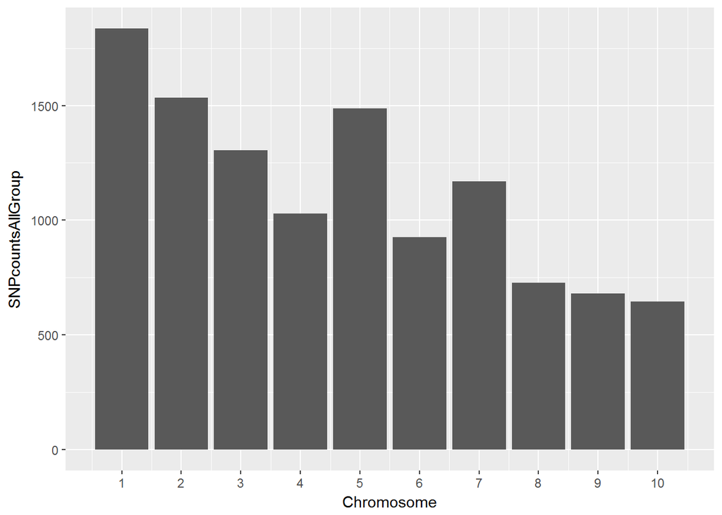

```r
# To plot with all the SNPs in each chromosome, including all the groups
ggplot(data = SNPbyChr2) + geom_col (mapping=aes(x=Chromosome, y=SNPcountsAllGroup)) + scale_x_continuous(breaks = c(1:10))
```

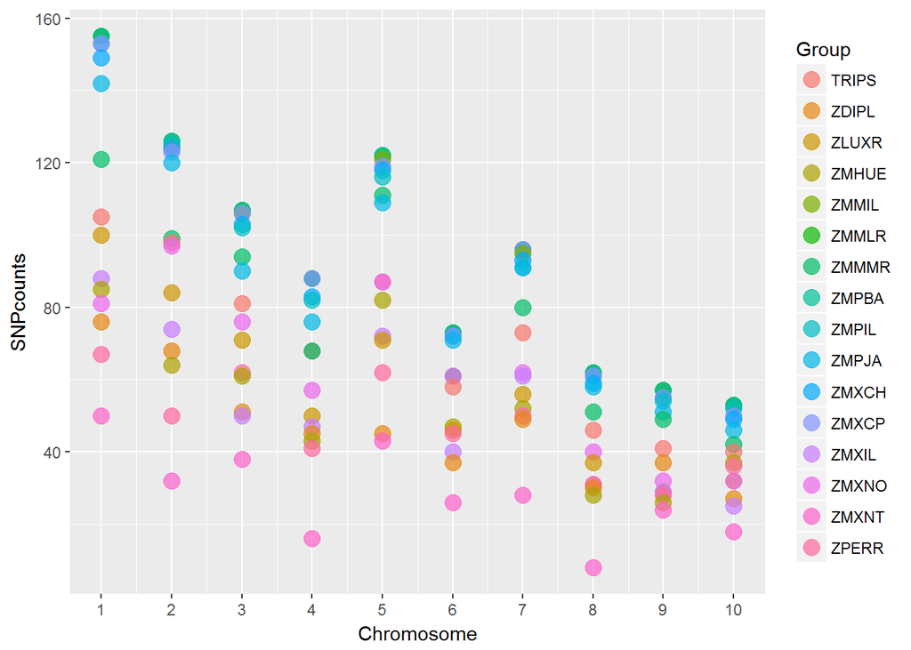

```r
ggsave("../Output/SNPsPerChr.png", width =6, height=5)

# To plot the number of SNPs from each group in each chromosome. Each group is color coded differently.
ggplot(data = SNPbyChr) + geom_point (mapping=aes(x=Chromosome, y=SNPcounts, color= Group),size=4,alpha=0.7) + scale_x_continuous(breaks = c(1:10))
```

```r
ggsave("../Output/SNPsPerChrByGroup.png", width =6, height=5)
```

This result shows us that different groups have different level of multi-allelic SNPs. ZMMIL, ZMMLR, ZMPBA, ZMPIL, and ZMXCP tends to have more multi-allelic SNPs than ZPERR, ZMXNT, ZDIPL, and ZMXNO.

# Missing data and amount of heterozygosity

# Reshape for heterozygous and missing data

```r
# Create a function to convert Heterozygous to H, and missing to NA
hetNA <- function (x) {
  if (x == "A/A"| x =="T/T" | x =="C/C"| x =="G/G") {
    return("Homozygous")
  }else if (x == "?/?"){
    return("NA")
  }else{
    return("Heterozygous")
  }
}

species <- function (x) {
  if(x=='ZMMIL'|x=='ZMMLR'|x=='ZMMMR'){
    return("Maize")
  }else if(x== 'ZMPBA'| x=='ZMPIL'|x=='ZMPJA'){
    return("Teosinte")
  }else {
    return("Other")
  }
}

# Create a new column with name HetNA
Geno2_melt_SNPinfo_HetNA <- Geno2_melt_SNPinfo
Geno2_melt_SNPinfo_HetNA$HetNA <- sapply(Geno2_melt_SNPinfo_HetNA$SNP_call, hetNA)
Geno2_melt_SNPinfo_HetNA$Species <- sapply(Geno2_melt_SNPinfo_HetNA$Group, species)
Geno2_melt_SNPinfo_HetNA <- as.tibble(Geno2_melt_SNPinfo_HetNA)
Geno2_melt_SNPinfo_HetNA$Sample_ID <- as.character(Geno2_melt_SNPinfo_HetNA$Sample_ID)

tail(Geno2_melt_SNPinfo_HetNA, n=10L) # To check if the conversion was successful
```

```
## # A tibble: 10 x 8
##    SNP_ID     Sample_ID Group SNP_call Chromosome Position  HetNA  Species
##    <fct>      <chr>     <chr> <chr>         <int> <chr>     <chr>  <chr>
##  1 PZD00075.2 S0351     ZMMIL C/C              10 146599484 Homoz~ Maize
##  2 PZD00075.2 S1602     ZMMIL C/C              10 146599484 Homoz~ Maize
##  3 PZD00075.2 WB0022a   ZMMIL C/C              10 146599484 Homoz~ Maize
##  4 PZD00075.2 CU0200    ZMMIL C/C              10 146599484 Homoz~ Maize
##  5 PZD00075.2 SYN262    ZMMIL C/C              10 146599484 Homoz~ Maize
##  6 PZD00075.2 S0398     ZMMIL ?/?              10 146599484 NA     Maize
##  7 PZD00075.2 S1636     ZMMIL ?/?              10 146599484 NA     Maize
##  8 PZD00075.2 CU0201    ZMMIL C/C              10 146599484 Homoz~ Maize
##  9 PZD00075.2 S0215     ZMMIL C/C              10 146599484 Homoz~ Maize
## 10 PZD00075.2 CU0202    ZMMIL C/C              10 146599484 Homoz~ Maize
```

```r
Geno2_melt_SNPinfo_HetNA <- arrange(Geno2_melt_SNPinfo_HetNA, Group, Sample_ID)
head(Geno2_melt_SNPinfo_HetNA, n=10L)
```

```
## # A tibble: 10 x 8
##    SNP_ID      Sample_ID Group SNP_call Chromosome Position  HetNA Species
##    <fct>       <chr>     <chr> <chr>         <int> <chr>     <chr> <chr>
##  1 an1.4       SL-10     TRIPS C/C               1 240498509 Homo~ Other
##  2 id1.3       SL-10     TRIPS T/T               1 238902078 Homo~ Other
##  3 PZA00010.5  SL-10     TRIPS ?/?               1 119703101 NA    Other
##  4 PZA00013.10 SL-10     TRIPS ?/?               1 263276247 NA    Other
##  5 PZA00013.11 SL-10     TRIPS C/C               1 263276005 Homo~ Other
##  6 PZA00013.9  SL-10     TRIPS T/T               1 263276335 Homo~ Other
##  7 PZA00017.1  SL-10     TRIPS G/G               1 35620725  Homo~ Other
##  8 PZA00050.9  SL-10     TRIPS A/A               1 295459549 Homo~ Other
##  9 PZA00081.17 SL-10     TRIPS ?/?               1 45675053  NA    Other
## 10 PZA00098.14 SL-10     TRIPS C/C               1 161472433 Homo~ Other
```

```r
# To plot each sample with homozygous, heterozygous, and NA across SNP sites.
SampleHetCounts <- Geno2_melt_SNPinfo_HetNA %>%
  group_by(Sample_ID,HetNA) %>%
  summarise(HetNA_count=n())
head(SampleHetCounts)
```

```
## # A tibble: 6 x 3
## # Groups:   Sample_ID [2]
##   Sample_ID HetNA        HetNA_count
##   <chr>     <chr>              <int>
## 1 BKN_001   Heterozygous         115
## 2 BKN_001   Homozygous           710
## 3 BKN_001   NA                   114
## 4 BKN_002   Heterozygous          84
## 5 BKN_002   Homozygous           754
## 6 BKN_002   NA                   101
```

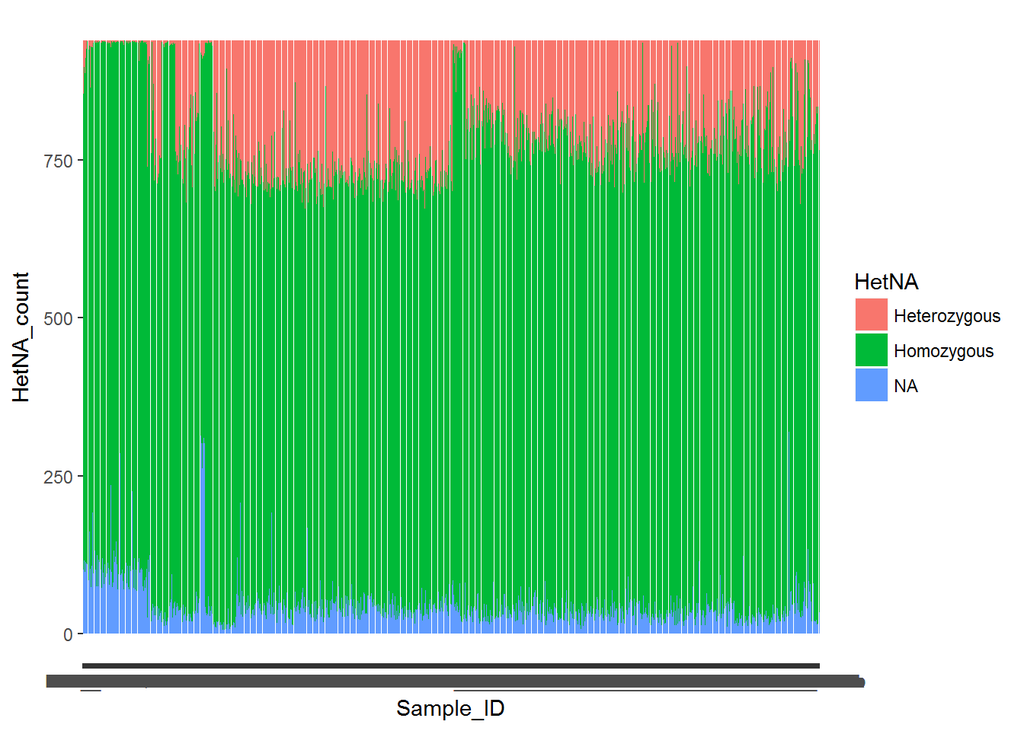

```r
ggplot(data=SampleHetCounts) + geom_bar(mapping=aes(x=Sample_ID, y=HetNA_count, fill=HetNA),stat = "identity")
```

```r
ggsave("../Output/SampleHetHomoNA.png", width =10, height=5)

# To plot counts of each group with homozygous, heterozygous, and NA across SNP sites.
GroupHetCounts <- Geno2_melt_SNPinfo_HetNA %>%
  group_by(Group,HetNA) %>%
  summarise(HetNA_count=n())
head(GroupHetCounts)
```

```
## # A tibble: 6 x 3
## # Groups:   Group [2]
##   Group HetNA        HetNA_count
##   <chr> <chr>              <int>
## 1 TRIPS Heterozygous         637
## 2 TRIPS Homozygous         13610
## 3 TRIPS NA                  6411
## 4 ZDIPL Heterozygous         488
## 5 ZDIPL Homozygous         12111
## 6 ZDIPL NA                  1486
```

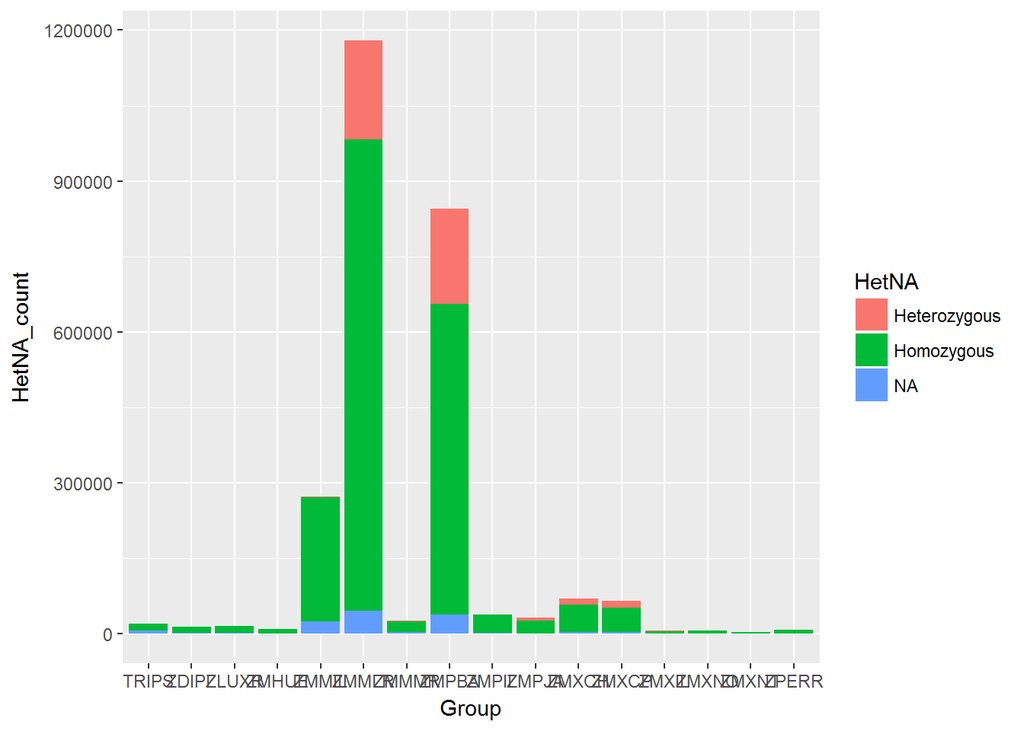

```r
ggplot(data=GroupHetCounts) + geom_bar(mapping=aes(x=Group, y=HetNA_count, fill=HetNA),stat = "identity")
```

```r
ggsave("../Output/GroupHetHomoNA.png", width =10, height=5)

# To plot proportion of each group with homozygous, heterozygous, and NA across SNP sites
# Since the goem_bar with position=fill with the full data takes very long time and memory to run, I calculated the proporation seperately and used it as y input to get the proportion.
GroupTotal <- Geno2_melt_SNPinfo_HetNA %>%
  group_by(Group) %>%
  summarise(Grouptotal=n())
head(GroupTotal)
```

```
## # A tibble: 6 x 2
##   Group Grouptotal
##   <chr>      <int>
## 1 TRIPS      20658
## 2 ZDIPL      14085
## 3 ZLUXR      15963
## 4 ZMHUE       9390
## 5 ZMMIL     272310
## 6 ZMMLR    1179384
```

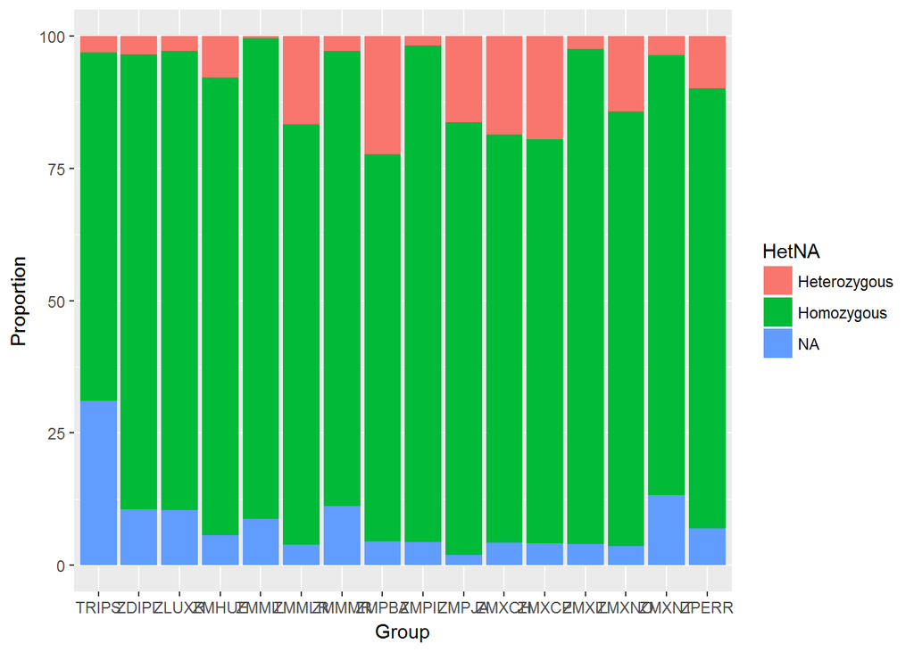

```r
GroupHetProp <- merge(GroupHetCounts,GroupTotal,by="Group")
GroupHetProp <- mutate(GroupHetProp, Proportion = (HetNA_count/Grouptotal)*100)

ggplot(data=GroupHetProp) + geom_bar(mapping=aes(x=Group, y=Proportion, fill=HetNA),stat = "identity")
```

```r
ggsave("../Output/GroupHetHomoNAProp.png", width =10, height=5)
```

# My own visualization

I would like to see if the heterozygous status across the positions in Chromosome 1, and how they are different for each group.

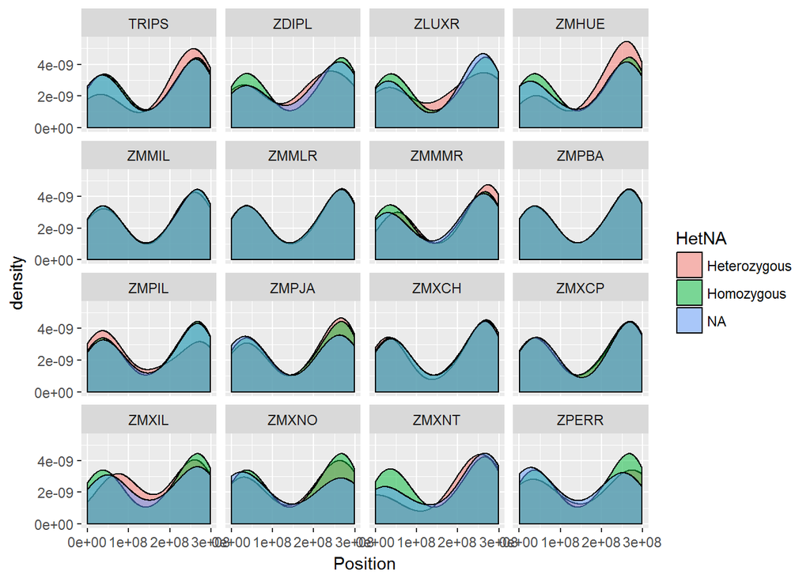

```r
Geno2_melt_SNPinfo_HetNA$Position <- as.integer(Geno2_melt_SNPinfo_HetNA$Position)
Chr1SNP <- Geno2_melt_SNPinfo_HetNA %>%
  filter(Chromosome == 1) %>%
  arrange(Position) %>%
  group_by(Group,HetNA,Position) %>%
  summarise(n_rows=n())

ggplot(data=Chr1SNP)+geom_density(mapping=aes(x=Position,fill=HetNA),alpha=0.5) + facet_wrap(~Group)
```

```r
ggsave("../Output/Chr1SNP.png", width =10, height=5)
```